# Motivation

Build a movie recommendation system that utilizes consumer reviews across multiple popular movie review websites. Not a single review website has the dominating power so that the recommender system has a distributed built-in.

a **Recommendation System** is a filtration program whose prime goal is to predict the “rating” or “preference” of a user towards a domain-specific item or item, here a movie.

- #### Content-based Filtering

  This filtration strategy is based on the data provided about the items. The algorithm recommends products that are **similar** to the ones that a user has liked in the **past**. This similarity (generally cosine similarity) is computed from the data we have about the items as well as the user’s past preferences.

  For example, if a user likes movies such as ‘The Prestige’ then we can recommend him the movies of ‘Christian Bale’ or movies with the genre ‘Thriller’ or maybe even movies directed by ‘Christopher Nolan’.So what happens here the recommendation system checks the past preferences of the user and find the film “The Prestige”, then tries to find similar movies to that using the information available in the database such as the lead actors, the director, genre of the film, production house, etc and based on this information find movies similar to “The Prestige”.

  #### Disadvantages
  1. Different products do not get much **exposure** to the user.
  2. Businesses cannot be expanded as the user does not try different types of products.
- #### Collaborative Filtering

  This filtration strategy is based on the combination of the user’s behavior and comparing and contrasting that with **other users’** behavior in the database. The history of **all users** plays an important role in this algorithm. The main difference between content-based filtering and collaborative filtering that in the latter, the **interaction of all users with the items** influences the recommendation algorithm while for content-based filtering only the **concerned user’s data** is taken into account.

  There are multiple ways to implement collaborative filtering but the main concept to be grasped is that in collaborative filtering **multiple** user’s data influences the outcome of the recommendation. and doesn’t depend on **only one user’s data** for modeling.

  There are 2 types of collaborative filtering algorithms:
  - #### User-based Collaborative filtering

    The basic idea here is to find users that have **similar past preference patterns** as the user ‘A’ has had and then recommending him or her items liked by those similar users which ‘A’ has not encountered yet. This is achieved by making a matrix of items each user has rated/viewed/liked/clicked depending upon the task at hand, and then computing the similarity score between the users and finally recommending items that the concerned user isn’t aware of but users similar to him/her are and liked it.

    For example, if the user ‘A’ likes ‘Batman Begins’, ‘Justice League’ and ‘The Avengers’ while the user ‘B’ likes ‘Batman Begins’, ‘Justice League’ and ‘Thor’ then they have similar interests because we know that these movies belong to the super-hero genre. So, there is a high probability that the user ‘A’ would like ‘Thor’ and the user ‘B’ would like The Avengers’.

    Disadvantages
    1. People are **fickle-minded** i.e their taste change from time to time and as this algorithm is based on user similarity it may pick up initial similarity patterns between 2 users who after a while may have completely different preferences.
    2. There are many **more users than items** therefore it becomes very difficult to maintain such large matrices and therefore needs to be recomputed very regularly.
    3. This algorithm is very susceptible to **shilling attacks** where fake users profiles consisting of biased preference patterns are used to manipulate key decisions.

```
-   #### Item-based Collaborative Filtering

    The concept in this case is to **find similar movies instead of similar users** and then recommending similar movies to that ‘A’ has had in his/her past preferences. This is executed by finding every pair of items that were rated/viewed/liked/clicked by the same user, then measuring the similarity of those rated/viewed/liked/clicked across all user who rated/viewed/liked/clicked both, and finally recommending them based on similarity scores.

    Here, for example, we take 2 movies ‘A’ and ‘B’ and check their ratings by all users who have rated both the movies and based on the similarity of these ratings, and based on this rating similarity by users who have rated both we find similar movies. So if most common users have rated ‘A’ and ‘B’ both similarly and it is highly probable that ‘A’ and ‘B’ are similar, therefore if someone has watched and liked ‘A’ they should be recommended ‘B’ and vice versa.

    #### Advantages over User-based Collaborative Filtering

    1.  Unlike people’s taste, **movies don’t change**.
    2.  There are usually a lot **fewer items than people,** therefore easier to maintain and compute the matrices.
    3.  Shilling attacks are much harder because **items cannot be faked**.
```

#### Disadvantages

1. Different products do not get much **exposure** to the user.
2. Businesses cannot be expanded as the user does not try different types of products.

The genre approach provides the most effective means for understanding, analyzing and appreciating the Hollywood cinema. Taking into account not only the formal and aesthetic aspects of feature filmmaking, but various other cultural aspects as well, the genre approach treats movie production as a dynamic process of exchange between the film industry and its audience. This process, embodied by the Hollywood studio system, has been sustained primarily through genres, those popular narrative formulas like the Western, musical and gangster film, which have dominated the screen arts throughout this century.

Connect to [[Brett Danaher]]'s research background, using similar designs as [[Erik Broynjofsson job2vec]] and [[Paramvver Dhillon news2vec]].

MovieLens Movie Catetgories:

- 1. Classic, masterpiece, quotable
- 1. Action, fun movie, special effects
- 1. dramatic, good acting, intense
- 1. blood, dark humor, social commentary
- 1. computer animation, good versus evil, mythology
- 1. chick flick, feel good, touching

cannot share emotions (Tik Tok, short videos, selfie. retrospect, egoistic, self-centered, egocentric, swollen-headed, conceited.

Movie, book, music -- entertainment 1.0, Uni-Directal Media Games, Communities -- entertainment 2.0, Bi-Directional Media, interaction, engagement. Material Re-Organization.

It is easy for media to make blockbusters ubiquitous, but outgunned for things that are only for a small group of people.

Unbiased recommendation. Inequality.

Common Interest -> Collective Preferences.

Create a different type of recommender that learns the unique relationship without traditional user-item data available.

W2V is a shadow neural network that predicts a word given its context words in a sentence. Under a particular architecture.

After this shadow neural network is trained, you have a by-product that is the vector representation of all words. You can add, substract (multiply???) these vectors and uncover analogous relationships. The same thing might also be applied to movies.

What is the company, Tim, Will, Jon built on film recommendation ML algorithm??? Back to the 2000s?? ---- The Savage Beast Technologies company.

“ the prototype of the Music Genome—an enhanced Excel spreadsheet with about fifty musical “genes” analyzing about seven hundred and fifty songs; the genes were, in truth, a bit naïve: tempo—fast to slow; harmony—major or minor; danceable—low to high, plus a bunch of instruments. ”

It is all about granuality/ How many points are you going to assign to each category?

why 3 instead of 5? why 5 instead of 10? why 10 instead of 1000? ? generality vs personality.

# More to research

[] Garage.com, venture capital for Pandora.

[] the Music Genome Project (MGP). How many genes are there now for all the musci industry？

[] Katchdata's Movie Genome Project (MGP2??)

# Analogies

words -> movies context -> watch sequence???? What if we don't have the watch sequences?? -> movie tags??? losing position importance -> Or leave out movie contexts, only use the intrinsic word vector space?

What are the hidden assumptions of all these?

How to define taste of movies??

How do them difffer from those of music?

movie-cal taste means that“ On a surface level, one’s “musical taste” refers to the music that aligns with one’s personal preferences—and hence the commonly used term “musical preferences” as a more formal equivalent, particularly in academic literature.”

New York Times, The paradigm is shifting.

What does this mean to traditional distribution mode? Offline theaters may not have bargaining powers any more. Like the old music disc companies???

move our focus from feature-based learning to relation-based learning and more specifically, embeddings, because relations of tuples can be modeled efficiently even with sparse input data. More precisely, we treat each movie as a vertice in a graph that has edges to other vertices (movies) that model arbitrary relations between those movies.

## Graph NNs Approach

https://raberrytv.wordpress.com/2015/12/31/movie2vec-adapting-word-embeddings-for-movies/

# Previous Movie2Vecs

[output not shown]

# Quantatitive Study of Movie Box Sales, Box Office Performance (BOP)

| Themes | Authors |
| --- | --- |
| *Audience reviews* | Dellarocas, Zhang, and Awad ([2007](https://www.tandfonline.com/doi/full/10.1080/10632921.2021.2018375#)); Duan, Gu, and Whinston ([2008](https://www.tandfonline.com/doi/full/10.1080/10632921.2021.201… |
| *Professional critics* | Eliashberg and Shugan ([1997](https://www.tandfonline.com/doi/full/10.1080/10632921.2021.2018375#)); Basuroy, Chatterjee, and Ravid ([2003](https://www.tandfonline.com/doi/full/10.1080/10632921.2021.2… |
| *Word-of-mouth (WoM)* | Liu ([2006](https://www.tandfonline.com/doi/full/10.1080/10632921.2021.2018375#)); Moul ([2007](https://www.tandfonline.com/doi/full/10.1080/10632921.2021.2018375#)); Ding et al. ([2017](https://www.t… |
| *Volume versus valence* | Flanagin and Metzger ([2013](https://www.tandfonline.com/doi/full/10.1080/10632921.2021.2018375#)); Kim, Yoon, and Choi ([2019](https://www.tandfonline.com/doi/full/10.1080/10632921.2021.2018375#)) |
| *Reviews between arthouse and mainstream movies* | Gemser, Van Oostrum, and Leenders ([2007](https://www.tandfonline.com/doi/full/10.1080/10632921.2021.2018375#)) |
| *Professional critics versus online reviews* | Chakravarty, Liu, and Mazumdar ([2010](https://www.tandfonline.com/doi/full/10.1080/10632921.2021.2018375#)); Kim, Park, and Park ([2013](https://www.tandfonline.com/doi/full/10.1080/10632921.2021.201… |
| *Reviews on different genre* | Wanderer ([2011](https://doi.org/10.2190/EM.29.1.c)) |

# Datasets

### Context

These files contain metadata for all 45,000 movies listed in the Full MovieLens Dataset. The dataset consists of movies released on or before July 2017. Data points include cast, crew, plot keywords, budget, revenue, posters, release dates, languages, production companies, countries, TMDB vote counts and vote averages.

This dataset also has files containing 26 million ratings from 270,000 users for all 45,000 movies. Ratings are on a scale of 1-5 and have been obtained from the official GroupLens website.

### Content

This dataset consists of the following files:

**movies_metadata.csv:** The main Movies Metadata file. Contains information on 45,000 movies featured in the Full MovieLens dataset. Features include posters, backdrops, budget, revenue, release dates, languages, production countries and companies.

**keywords.csv:** Contains the movie plot keywords for our MovieLens movies. Available in the form of a stringified JSON Object.

**credits.csv:** Consists of Cast and Crew Information for all our movies. Available in the form of a stringified JSON Object.

**links.csv:** The file that contains the TMDB and IMDB IDs of all the movies featured in the Full MovieLens dataset.

**links_small.csv:** Contains the TMDB and IMDB IDs of a small subset of 9,000 movies of the Full Dataset.

**ratings_small.csv:** The subset of 100,000 ratings from 700 users on 9,000 movies.

The Full MovieLens Dataset consisting of 26 million ratings and 750,000 tag applications from 270,000 users on all the 45,000 movies in this dataset can be accessed [here](https://grouplens.org/datasets/movielens/latest/)

### Acknowledgements

This dataset is an ensemble of data collected from TMDB and GroupLens.  
The Movie Details, Credits and Keywords have been collected from the TMDB Open API. This product uses the TMDb API but is not endorsed or certified by TMDb. Their API also provides access to data on many additional movies, actors and actresses, crew members, and TV shows. You can try it for yourself [here](https://www.themoviedb.org/documentation/api).

The Movie Links and Ratings have been obtained from the Official GroupLens website. The files are a part of the dataset available [here](https://grouplens.org/datasets/movielens/latest/)

### Inspiration

This dataset was assembled as part of my second Capstone Project for Springboard's [Data Science Career Track](https://www.springboard.com/workshops/data-science-career-track). I wanted to perform an extensive EDA on Movie Data to narrate the history and the story of Cinema and use this metadata in combination with MovieLens ratings to build various types of Recommender Systems.

Both my notebooks are available as kernels with this dataset: [The Story of Film](https://www.kaggle.com/rounakbanik/the-story-of-film) and [Movie Recommender Systems](https://www.kaggle.com/rounakbanik/movie-recommender-systems)

Some of the things you can do with this dataset:  
Predicting movie revenue and/or movie success based on a certain metric. What movies tend to get higher vote counts and vote averages on TMDB? Building Content Based and Collaborative Filtering Based Recommendation Engines.

# Theoretical background

**“Nobody knows anything… Not one person in the entire motion picture field knows for a certainty what's going to work [at the box office].”**

- William Goldman, a two-time Oscar-winning screenwriter

## conceptual model

from IS construct perspective, use movie meta data and platform review data to reveal consumer's real preference.

# Empirical Design

## Lab Experiment

Find two similar groups of students who are interested in the movie industry.

One is from the University of California, Irvine and the other is from Chapman University.

One is recommended by the Collaborative Filtering algorithm and the other is recommended by the Content Based algorithm.

# 0. Executive Summary

We use various data sources to build our movie2vec model. 1. Background is using IMDb for general understanding of the Movie industry. We plot the distribution of movie production years, director ages, movie ratings. 2. Movielens is using user-movie watch sequence to model a distributed representation of movies, i.e. Movie2Vec representations. We use the movie2vec model to predict the movie ratings of a user and recommend movies to a user.

```python
from IPython.core.display import display, HTML
display(HTML("<style>.container { width:100% !important; }</style>"))
```

# 1. Background

Use unique movie review data to build a `Movie2Vec` recommender system.

```python
%matplotlib inline


import pandas as pd
import gzip


pd.set_option('display.max_columns', None)
pd.set_option('display.max_rows', None)
pd.set_eng_float_format(accuracy=3, use_eng_prefix=True)
pd.set_option('display.float_format', lambda x: '%.3f' % x)


from sklearn.feature_extraction.text import CountVectorizer

import pycountry




import numpy as np
import matplotlib.pyplot as plt
import seaborn as sns
from matplotlib import rcParams
rcParams['figure.figsize'] = 12, 12

import warnings
warnings.filterwarnings('ignore')

import sweetviz as sv

import sklearn
from sklearn.linear_model import LogisticRegression
from sklearn.tree import DecisionTreeClassifier
from sklearn.ensemble import RandomForestClassifier, GradientBoostingClassifier
from sklearn.neighbors import KNeighborsClassifier
from sklearn.naive_bayes import GaussianNB, MultinomialNB
from sklearn.svm import SVC
from sklearn import model_selection
from sklearn.model_selection import train_test_split, GridSearchCV, \
    cross_val_score, RepeatedStratifiedKFold, StratifiedKFold
from sklearn.metrics import plot_precision_recall_curve, classification_report,\
    plot_confusion_matrix, plot_roc_curve
```

```python
import sys
print(sys.version)
```

```
3.9.7 (default, Sep 16 2021, 16:59:28) [MSC v.1916 64 bit (AMD64)]
```

```python
def show_values(axs, orient="v", space=.01, precision=2):
    def _single(ax):
        if orient == "v":
            for p in ax.patches:
                _x = p.get_x() + p.get_width() / 2
                _y = p.get_y() + p.get_height() + (p.get_height()*0.01)
                value = ('{:.'+str(precision)+'f}').format(p.get_height())
                ax.text(_x, _y, value, ha="center")
        elif orient == "h":
            for p in ax.patches:
                _x = p.get_x() + p.get_width() + float(space)
                _y = p.get_y() + p.get_height() - (p.get_height()*0.5)
                value = ('{:.'+str(precision)+'f}').format(p.get_width())
                ax.text(_x, _y, value, ha="left")

    if isinstance(axs, np.ndarray):
        for idx, ax in np.ndenumerate(axs):
            _single(ax)
    else:
        _single(axs)
```

# 1. IMDb

IMDb’s dataset is available online and refreshed daily. This version is retrieved on Feb 8th, 2022. Each dataset is contained in a gzipped, tab-separated-values (TSV) formatted file in the UTF-8 character set. The first line in each file contains headers that describe what is in each column. A ‘\N’ is used to denote that a particular field is missing or null for that title/name. https://www.imdb.com/interfaces/. The available datasets are as follows:

## AKAS - Movie shown in these regions

#### title.akas.tsv.gz - Contains the following information for titles:

- titleId (string) - a tconst, an alphanumeric unique identifier of the title.
- ordering (integer) – a number to uniquely identify rows for a given titleId.
- title (string) – the localized title.
- region (string) - the region for this version of the title.
- language (string) - the language of the title.
- types (array) - Enumerated set of attributes for this alternative title. One or more of the following: "alternative", "dvd", "festival", "tv", "video", "working", "original", "imdbDisplay". New values may be added in the future without warning.
- attributes (array) - Additional terms to describe this alternative title, not enumerated.
- isOriginalTitle (boolean) – 0: not original title; 1: original title.

```python
with gzip.open('../01PrimaryData/IMDb/title.akas.tsv.gz') as f:
    akas = pd.read_csv(f, sep='\t',na_values='\\N', quoting=3)
```

```python
akas.head()
```

|  | titleId | ordering | title | region | language | types | attributes | isOriginalTitle |
| --- | --- | --- | --- | --- | --- | --- | --- | --- |
| 0 | tt0000001 | 1 | Карменсіта | UA | NaN | imdbDisplay | NaN | 0.000 |
| 1 | tt0000001 | 2 | Carmencita | DE | NaN | NaN | literal title | 0.000 |
| 2 | tt0000001 | 3 | Carmencita - spanyol tánc | HU | NaN | imdbDisplay | NaN | 0.000 |
| 3 | tt0000001 | 4 | Καρμενσίτα | GR | NaN | imdbDisplay | NaN | 0.000 |
| 4 | tt0000001 | 5 | Карменсита | RU | NaN | imdbDisplay | NaN | 0.000 |

```python
akas.describe(include='all')
```

|  | titleId | ordering | title | region | language | types | attributes | isOriginalTitle |
| --- | --- | --- | --- | --- | --- | --- | --- | --- |
| count | 31187805 | 31.188M | 31187801 | 29276222 | 25082539 | 5234132 | 236908 | 31.186M |
| unique | 6170008 | NaN | 3902885 | 246 | 104 | 23 | 187 | NaN |
| top | tt0168366 | NaN | Episodio #1.1 | FR | ja | imdbDisplay | transliterated title | NaN |
| freq | 177 | NaN | 85232 | 3704075 | 3574649 | 3172290 | 26297 | NaN |
| mean | NaN | 4.028 | NaN | NaN | NaN | NaN | NaN | 58.965m |
| std | NaN | 3.496 | NaN | NaN | NaN | NaN | NaN | 235.560m |
| min | NaN | 1.000 | NaN | NaN | NaN | NaN | NaN | 0.000 |
| 25% | NaN | 2.000 | NaN | NaN | NaN | NaN | NaN | 0.000 |
| 50% | NaN | 4.000 | NaN | NaN | NaN | NaN | NaN | 0.000 |
| 75% | NaN | 6.000 | NaN | NaN | NaN | NaN | NaN | 0.000 |
| max | NaN | 177.000 | NaN | NaN | NaN | NaN | NaN | 1.000 |

```python
colors = sns.color_palette()
```

```python
sv.analyze(akas.drop(['titleId'],axis=1), 'region').show_notebook(layout='widescreen')
```

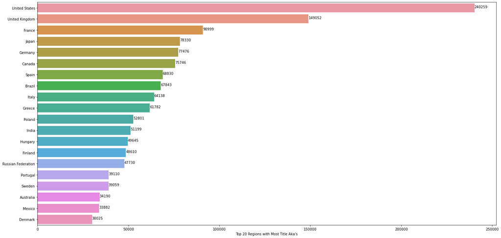

```python
country_counts = akas.region.value_counts()
country_names = [pycountry.countries.get(alpha_2=coun).name for coun in country_counts.drop(["XWW","XWG"]).index[:20]]
counts = country_counts.drop(["XWW","XWG"]).values[:20]

plt.figure(figsize=(24,12))
p1=sns.barplot(x=counts,y=country_names,orient="h")
plt.xlabel("Top 20 Regions with Most Title Aka's")

show_values(p1, "h", space=.01, precision=0)
```

## BASICS - Basic information about the movie

#### title.basics.tsv.gz - Contains the following information for titles:

- tconst (string) - alphanumeric unique identifier of the title.
- titleType (string) – the type/format of the title (e.g. movie, short, tvseries, tvepisode, video, etc).
- primaryTitle (string) – the more popular title / the title used by the filmmakers on promotional materials at the point of release.
- originalTitle (string) - original title, in the original language.
- isAdult (boolean) - 0: non-adult title; 1: adult title.
- startYear (YYYY) – represents the release year of a title. In the case of TV Series, it is the series start year.
- endYear (YYYY) – TV Series end year. for all other title types.
- runtimeMinutes – primary runtime of the title, in minutes.
- genres (string array) – includes up to three genres associated with the title.

```python
with gzip.open('../01PrimaryData/IMDb/title.basics.tsv.gz') as f:
    basics = pd.read_csv(f, sep='\t', na_values='\\N', quoting=3)
```

```python
# drop nan rows
basics = basics.dropna(subset=['titleType','startYear','runtimeMinutes'])
basics = basics[basics.titleType.isin(['movie','tvMovie'])]
basics = basics[basics.isAdult==0]
del basics['isAdult']
```

```python
basics['startYear'] = basics['startYear'].astype(int, errors='ignore')
basics['endYear'] = basics['endYear'].astype(int, errors='ignore')
basics['runtimeMinutes'] = basics['runtimeMinutes'].astype(int, errors='ignore')
# basics['titleType'] = basics['titleType'].astype('category')
# basics['isAdult'] = basics['isAdult'].astype('category')
# basics['isAdult'].cat.categories = ['False', 'True']
```

```python
# basics[~ basics['runtimeMinutes'].astype(str).fillna('').str.isnumeric()]
# basics[pd.to_numeric(basics.runtimeMinutes, errors='coerce').null()]
```

```python
basics[basics.startYear.isnull()]
```

|  | tconst | titleType | primaryTitle | originalTitle | startYear | endYear | runtimeMinutes | genres |
| --- | --- | --- | --- | --- | --- | --- | --- | --- |

```python
basics.head(50)
```

|  | tconst | titleType | primaryTitle | originalTitle | startYear | endYear | runtimeMinutes | genres |
| --- | --- | --- | --- | --- | --- | --- | --- | --- |
| 498 | tt0000502 | movie | Bohemios | Bohemios | 1905 | NaN | 100 | NaN |
| 570 | tt0000574 | movie | The Story of the Kelly Gang | The Story of the Kelly Gang | 1906 | NaN | 70 | Action,Adventure,Biography |
| 587 | tt0000591 | movie | The Prodigal Son | L'enfant prodigue | 1907 | NaN | 90 | Drama |
| 672 | tt0000679 | movie | The Fairylogue and Radio-Plays | The Fairylogue and Radio-Plays | 1908 | NaN | 120 | Adventure,Fantasy |
| 1172 | tt0001184 | movie | Don Juan de Serrallonga | Don Juan de Serrallonga | 1910 | NaN | 58 | Adventure,Drama |
| 1273 | tt0001285 | movie | The Life of Moses | The Life of Moses | 1909 | NaN | 50 | Biography,Drama,Family |
| 1485 | tt0001498 | movie | The Battle of Trafalgar | The Battle of Trafalgar | 1911 | NaN | 51 | War |
| 1578 | tt0001592 | movie | In the Prime of Life | Ekspeditricen | 1911 | NaN | 52 | Drama |
| 1616 | tt0001630 | movie | Der fremde Vogel | Der fremde Vogel | 1911 | NaN | 45 | NaN |
| 1739 | tt0001756 | movie | Lucha por la herencia | Lucha por la herencia | 1911 | NaN | 92 | NaN |
| 1773 | tt0001790 | movie | Les Misérables, Part 1: Jean Valjean | Les misérables - Époque 1: Jean Valjean | 1913 | NaN | 60 | Drama |
| 1794 | tt0001812 | movie | Oedipus Rex | Oedipus Rex | 1911 | NaN | 56 | Drama |
| 1872 | tt0001892 | movie | Den sorte drøm | Den sorte drøm | 1911 | NaN | 53 | Drama |
| 1891 | tt0001911 | movie | Nell Gwynne | Sweet Nell of Old Drury | 1911 | NaN | 50 | Biography,Drama,History |
| 1941 | tt0001964 | movie | The Traitress | Die Verräterin | 1911 | NaN | 48 | Drama |
| 2002 | tt0002026 | movie | Anny - Story of a Prostitute | Anny - en gatepiges roman | 1912 | NaN | 68 | Drama,Romance |
| 2069 | tt0002094 | movie | Charles IV | Charles IV | 1912 | NaN | 50 | NaN |
| 2076 | tt0002101 | movie | Cleopatra | Cleopatra | 1912 | NaN | 100 | Drama,History |
| 2105 | tt0002130 | movie | Dante's Inferno | L'Inferno | 1911 | NaN | 71 | Adventure,Drama,Fantasy |
| 2128 | tt0002153 | movie | The Great Circus Catastrophe | Dødsspring til hest fra cirkuskuplen | 1912 | NaN | 45 | Drama |
| 2161 | tt0002186 | movie | The Flying Circus | Den flyvende cirkus | 1912 | NaN | 46 | Drama |
| 2174 | tt0002199 | movie | From the Manger to the Cross; or, Jesus of Naz... | From the Manger to the Cross; or, Jesus of Naz... | 1912 | NaN | 60 | Biography,Drama |
| 2289 | tt0002315 | movie | El lobo de la sierra | El lobo de la sierra | 1912 | NaN | 76 | NaN |
| 2396 | tt0002423 | movie | Passion | Madame DuBarry | 1919 | NaN | 85 | Biography,Drama,Romance |
| 2398 | tt0002425 | movie | Paul J. Rainey's African Hunt | Paul J. Rainey's African Hunt | 1912 | NaN | 60 | Documentary |
| 2405 | tt0002432 | movie | Los Pirineos de Port-Bou a Andorra | Los Pirineos de Port-Bou a Andorra | 1912 | NaN | 58 | NaN |
| 2418 | tt0002445 | movie | Quo Vadis? | Quo Vadis? | 1913 | NaN | 120 | Drama,History |
| 2425 | tt0002452 | movie | The Independence of Romania | Independenta Romaniei | 1912 | NaN | 120 | History,War |
| 2434 | tt0002461 | movie | The Life and Death of King Richard III | Richard III | 1912 | NaN | 55 | Drama |
| 2473 | tt0002500 | movie | The Black Chancellor | Den sorte kansler | 1912 | NaN | 48 | Drama |
| 2487 | tt0002514 | movie | Saved in Mid-Air | De svarta maskerna | 1912 | NaN | 60 | Drama |
| 2561 | tt0002588 | movie | Zigomar contre Nick Carter | Zigomar contre Nick Carter | 1912 | NaN | 48 | Crime,Thriller |
| 2598 | tt0002625 | movie | Ana Kadova | Ana Kadova | 1913 | NaN | 92 | NaN |
| 2601 | tt0002628 | movie | Der Andere | Der Andere | 1913 | NaN | 48 | Drama,Thriller |
| 2619 | tt0002646 | movie | Atlantis | Atlantis | 1913 | NaN | 121 | Drama |
| 2642 | tt0002669 | movie | The Battle of Gettysburg | The Battle of Gettysburg | 1913 | NaN | 48 | Drama,War |
| 2658 | tt0002685 | movie | Blodets röst | Blodets röst | 1913 | NaN | 89 | Drama |
| 2716 | tt0002743 | movie | El Caín moderno | El Caín moderno | 1913 | NaN | 48 | NaN |
| 2740 | tt0002767 | movie | The Count of Monte Cristo | The Count of Monte Cristo | 1913 | NaN | 69 | Drama,History |
| 2774 | tt0002801 | movie | The Black Diamond | Le diamant noir | 1913 | NaN | 50 | NaN |
| 2793 | tt0002820 | movie | East Lynne | East Lynne | 1913 | NaN | 69 | Drama |
| 2795 | tt0002822 | movie | What 80 Million Women Want | What 80 Million Women Want | 1913 | NaN | 56 | Drama |
| 2805 | tt0002832 | movie | Evangeline | Evangeline | 1914 | NaN | 50 | Drama |
| 2817 | tt0002844 | movie | Fantômas: In the Shadow of the Guillotine | Fantômas - À l'ombre de la guillotine | 1913 | NaN | 54 | Crime,Drama |
| 2858 | tt0002885 | movie | From Dusk to Dawn | From Dusk to Dawn | 1913 | NaN | 90 | Drama |
| 2871 | tt0002898 | movie | Germinal; or, The Toll of Labor | Germinal | 1913 | NaN | 150 | Drama |
| 2890 | tt0002917 | movie | Brother Against Brother | Gränsfolken | 1913 | NaN | 51 | Drama |
| 2895 | tt0002922 | movie | Hamlet | Hamlet | 1913 | NaN | 64 | Drama |
| 2945 | tt0002973 | movie | Dr. Mawson in the Antarctic | Dr. Mawson in the Antarctic | 1913 | NaN | 68 | Documentary |
| 2978 | tt0003006 | movie | In the Bishop's Carriage | In the Bishop's Carriage | 1913 | NaN | 50 | Crime,Drama |

```python
basics.describe(include='all')
```

|  | tconst | titleType | primaryTitle | originalTitle | startYear | endYear | runtimeMinutes | genres |
| --- | --- | --- | --- | --- | --- | --- | --- | --- |
| count | 459090 | 459090 | 459090 | 459090 | 459090.000 | 0.000 | 459090.000 | 431050 |
| unique | 459090 | 2 | 409264 | 418312 | NaN | NaN | NaN | 1341 |
| top | tt0000502 | movie | Macbeth | Macbeth | NaN | NaN | NaN | Documentary |
| freq | 1 | 368082 | 51 | 49 | NaN | NaN | NaN | 84552 |
| mean | NaN | NaN | NaN | NaN | 1994.360 | NaN | 86.525 | NaN |
| std | NaN | NaN | NaN | NaN | 25.100 | NaN | 118.256 | NaN |
| min | NaN | NaN | NaN | NaN | 1896.000 | NaN | 1.000 | NaN |
| 25% | NaN | NaN | NaN | NaN | 1979.000 | NaN | 67.000 | NaN |
| 50% | NaN | NaN | NaN | NaN | 2004.000 | NaN | 87.000 | NaN |
| 75% | NaN | NaN | NaN | NaN | 2014.000 | NaN | 99.000 | NaN |
| max | NaN | NaN | NaN | NaN | 2027.000 | NaN | 51420.000 | NaN |

```python
# basics.describe(include='all')
```

[output not shown]

##### Movie Genres

[figure not shown]

```python
temp = basics.genres.dropna()
vec = CountVectorizer(token_pattern='(?u)\\b[\\w-]+\\b', analyzer='word').fit(temp)
bag_of_genres = vec.transform(temp)
unique_genres =  vec.get_feature_names()
genres = pd.DataFrame(bag_of_genres.todense(),columns=unique_genres,index=temp.index)
sorted_genres_perc = 100*pd.Series(genres.sum()).sort_values(ascending=False)/genres.shape[0]

plt.figure(figsize=(24,12))
p2=sns.barplot(x=sorted_genres_perc.values,y=sorted_genres_perc.index,orient="h")
plt.xlabel("Genre Percentage of IMDb Movies (%)")

show_values(p2, "h", space=.01, precision=2)
```

```python
# basics.describe(include='all')
```

##### Title Genres

```python
temp = basics.genres.dropna()
vec = CountVectorizer(token_pattern='(?u)\\b[\\w-]+\\b', analyzer='word').fit(temp)
bag_of_genres = vec.transform(temp)
unique_genres =  vec.get_feature_names()
genres = pd.DataFrame(bag_of_genres.todense(),columns=unique_genres,index=temp.index)
sorted_genres_perc = 100*pd.Series(genres.sum()).sort_values(ascending=False)/genres.shape[0]
```

[figure not shown]

```python
plt.figure(figsize=(24,12))
sns.barplot(x=sorted_genres_perc.values,y=sorted_genres_perc.index,orient="h")
plt.xlabel("Genre Percentage of IMDb Titles (%)")

for i,count in enumerate(sorted_genres_perc.values):
    plt.text(count, i, round(count,2), va="center")
```

```python
# now let's focus on only movies

akas = pd.merge(basics, akas, right_on='titleId', left_on='tconst')
```

```python
akas.head(50)
```

|  | tconst | titleType | primaryTitle | originalTitle | startYear | endYear | runtimeMinutes | genres | titleId | ordering | title | region | language | types | attributes | isOriginalTitle |
| --- | --- | --- | --- | --- | --- | --- | --- | --- | --- | --- | --- | --- | --- | --- | --- | --- |
| 0 | tt0000502 | movie | Bohemios | Bohemios | 1905 | NaN | 100 | NaN | tt0000502 | 1 | Bohemios | NaN | NaN | original | NaN | 1.000 |
| 1 | tt0000502 | movie | Bohemios | Bohemios | 1905 | NaN | 100 | NaN | tt0000502 | 2 | Bohemios | ES | NaN | imdbDisplay | NaN | 0.000 |
| 2 | tt0000574 | movie | The Story of the Kelly Gang | The Story of the Kelly Gang | 1906 | NaN | 70 | Action,Adventure,Biography | tt0000574 | 10 | The Story of the Kelly Gang | AU | NaN | imdbDisplay | NaN | 0.000 |
| 3 | tt0000574 | movie | The Story of the Kelly Gang | The Story of the Kelly Gang | 1906 | NaN | 70 | Action,Adventure,Biography | tt0000574 | 1 | Kelly bandájának története | HU | NaN | imdbDisplay | NaN | 0.000 |
| 4 | tt0000574 | movie | The Story of the Kelly Gang | The Story of the Kelly Gang | 1906 | NaN | 70 | Action,Adventure,Biography | tt0000574 | 2 | Ned Kelly and His Gang | AU | NaN | imdbDisplay | NaN | 0.000 |
| 5 | tt0000574 | movie | The Story of the Kelly Gang | The Story of the Kelly Gang | 1906 | NaN | 70 | Action,Adventure,Biography | tt0000574 | 3 | Priča o Kelijevoj bandi | RS | NaN | imdbDisplay | NaN | 0.000 |
| 6 | tt0000574 | movie | The Story of the Kelly Gang | The Story of the Kelly Gang | 1906 | NaN | 70 | Action,Adventure,Biography | tt0000574 | 4 | The Story of the Kelly Gang | GB | NaN | imdbDisplay | NaN | 0.000 |
| 7 | tt0000574 | movie | The Story of the Kelly Gang | The Story of the Kelly Gang | 1906 | NaN | 70 | Action,Adventure,Biography | tt0000574 | 5 | The Story of the Kelly Gang | NaN | NaN | original | NaN | 1.000 |
| 8 | tt0000574 | movie | The Story of the Kelly Gang | The Story of the Kelly Gang | 1906 | NaN | 70 | Action,Adventure,Biography | tt0000574 | 6 | The Story of the Kelly Gang | SG | en | imdbDisplay | NaN | 0.000 |
| 9 | tt0000574 | movie | The Story of the Kelly Gang | The Story of the Kelly Gang | 1906 | NaN | 70 | Action,Adventure,Biography | tt0000574 | 7 | The Story of the Kelly Gang | US | NaN | imdbDisplay | NaN | 0.000 |
| 10 | tt0000574 | movie | The Story of the Kelly Gang | The Story of the Kelly Gang | 1906 | NaN | 70 | Action,Adventure,Biography | tt0000574 | 8 | Ned Kelly and His Gang | NaN | NaN | NaN | NaN | 0.000 |
| 11 | tt0000574 | movie | The Story of the Kelly Gang | The Story of the Kelly Gang | 1906 | NaN | 70 | Action,Adventure,Biography | tt0000574 | 9 | Die Geschichte der Kelly Bande | DE | NaN | NaN | NaN | 0.000 |
| 12 | tt0000591 | movie | The Prodigal Son | L'enfant prodigue | 1907 | NaN | 90 | Drama | tt0000591 | 1 | L'enfant prodigue | FR | NaN | imdbDisplay | NaN | 0.000 |
| 13 | tt0000591 | movie | The Prodigal Son | L'enfant prodigue | 1907 | NaN | 90 | Drama | tt0000591 | 2 | L'enfant prodigue | NaN | NaN | original | NaN | 1.000 |
| 14 | tt0000591 | movie | The Prodigal Son | L'enfant prodigue | 1907 | NaN | 90 | Drama | tt0000591 | 3 | The Prodigal Son | US | NaN | NaN | NaN | 0.000 |
| 15 | tt0000679 | movie | The Fairylogue and Radio-Plays | The Fairylogue and Radio-Plays | 1908 | NaN | 120 | Adventure,Fantasy | tt0000679 | 1 | The Fairylogue and Radio-Plays | NaN | NaN | original | NaN | 1.000 |
| 16 | tt0000679 | movie | The Fairylogue and Radio-Plays | The Fairylogue and Radio-Plays | 1908 | NaN | 120 | Adventure,Fantasy | tt0000679 | 2 | The Fairylogue and Radio-Plays | GB | NaN | imdbDisplay | NaN | 0.000 |
| 17 | tt0000679 | movie | The Fairylogue and Radio-Plays | The Fairylogue and Radio-Plays | 1908 | NaN | 120 | Adventure,Fantasy | tt0000679 | 3 | The Fairylogue and Radio-Plays | US | NaN | imdbDisplay | NaN | 0.000 |
| 18 | tt0001184 | movie | Don Juan de Serrallonga | Don Juan de Serrallonga | 1910 | NaN | 58 | Adventure,Drama | tt0001184 | 1 | Don Juan de Serrallonga | NaN | NaN | original | NaN | 1.000 |
| 19 | tt0001184 | movie | Don Juan de Serrallonga | Don Juan de Serrallonga | 1910 | NaN | 58 | Adventure,Drama | tt0001184 | 2 | Don Juan de Serrallonga | ES | NaN | imdbDisplay | NaN | 0.000 |
| 20 | tt0001285 | movie | The Life of Moses | The Life of Moses | 1909 | NaN | 50 | Biography,Drama,Family | tt0001285 | 1 | Forty Years in the Land of the Midian | US | NaN | NaN | second part title | 0.000 |
| 21 | tt0001285 | movie | The Life of Moses | The Life of Moses | 1909 | NaN | 50 | Biography,Drama,Family | tt0001285 | 2 | Mózes élete | HU | NaN | imdbDisplay | NaN | 0.000 |
| 22 | tt0001285 | movie | The Life of Moses | The Life of Moses | 1909 | NaN | 50 | Biography,Drama,Family | tt0001285 | 3 | Moses lif i lefvande bilder | SE | NaN | imdbDisplay | NaN | 0.000 |
| 23 | tt0001285 | movie | The Life of Moses | The Life of Moses | 1909 | NaN | 50 | Biography,Drama,Family | tt0001285 | 4 | The Victory of Israel | US | NaN | NaN | fourth season title | 0.000 |
| 24 | tt0001285 | movie | The Life of Moses | The Life of Moses | 1909 | NaN | 50 | Biography,Drama,Family | tt0001285 | 5 | The Life of Moses | NaN | NaN | original | NaN | 1.000 |
| 25 | tt0001285 | movie | The Life of Moses | The Life of Moses | 1909 | NaN | 50 | Biography,Drama,Family | tt0001285 | 6 | The Life of Moses | US | NaN | imdbDisplay | NaN | 0.000 |
| 26 | tt0001285 | movie | The Life of Moses | The Life of Moses | 1909 | NaN | 50 | Biography,Drama,Family | tt0001285 | 7 | The Plagues of Egypt | US | NaN | NaN | third part title | 0.000 |
| 27 | tt0001285 | movie | The Life of Moses | The Life of Moses | 1909 | NaN | 50 | Biography,Drama,Family | tt0001285 | 8 | The Promised Land | US | NaN | NaN | fifth season title | 0.000 |
| 28 | tt0001498 | movie | The Battle of Trafalgar | The Battle of Trafalgar | 1911 | NaN | 51 | War | tt0001498 | 1 | The Battle of Trafalgar | GB | NaN | imdbDisplay | NaN | 0.000 |
| 29 | tt0001498 | movie | The Battle of Trafalgar | The Battle of Trafalgar | 1911 | NaN | 51 | War | tt0001498 | 2 | The Battle of Trafalgar | NaN | NaN | original | NaN | 1.000 |
| 30 | tt0001498 | movie | The Battle of Trafalgar | The Battle of Trafalgar | 1911 | NaN | 51 | War | tt0001498 | 3 | Slaget ved Trafalgar | DK | NaN | imdbDisplay | NaN | 0.000 |
| 31 | tt0001498 | movie | The Battle of Trafalgar | The Battle of Trafalgar | 1911 | NaN | 51 | War | tt0001498 | 4 | The Battle of Trafalgar | US | NaN | imdbDisplay | NaN | 0.000 |
| 32 | tt0001592 | movie | In the Prime of Life | Ekspeditricen | 1911 | NaN | 52 | Drama | tt0001592 | 1 | Ungdom och lättsinne | FI | sv | imdbDisplay | NaN | 0.000 |
| 33 | tt0001592 | movie | In the Prime of Life | Ekspeditricen | 1911 | NaN | 52 | Drama | tt0001592 | 2 | Ekspeditricen | DK | NaN | imdbDisplay | NaN | 0.000 |
| 34 | tt0001592 | movie | In the Prime of Life | Ekspeditricen | 1911 | NaN | 52 | Drama | tt0001592 | 3 | Nuoruus ja kevytmielisyys | FI | NaN | imdbDisplay | NaN | 0.000 |
| 35 | tt0001592 | movie | In the Prime of Life | Ekspeditricen | 1911 | NaN | 52 | Drama | tt0001592 | 4 | Kaupan myyjätär | FI | NaN | imdbDisplay | NaN | 0.000 |
| 36 | tt0001592 | movie | In the Prime of Life | Ekspeditricen | 1911 | NaN | 52 | Drama | tt0001592 | 5 | Ekspeditricen | NaN | NaN | original | NaN | 1.000 |
| 37 | tt0001592 | movie | In the Prime of Life | Ekspeditricen | 1911 | NaN | 52 | Drama | tt0001592 | 6 | In the Prime of Life | US | NaN | imdbDisplay | NaN | 0.000 |
| 38 | tt0001592 | movie | In the Prime of Life | Ekspeditricen | 1911 | NaN | 52 | Drama | tt0001592 | 7 | Ungdomsynd | SE | NaN | imdbDisplay | NaN | 0.000 |
| 39 | tt0001592 | movie | In the Prime of Life | Ekspeditricen | 1911 | NaN | 52 | Drama | tt0001592 | 8 | Die Jugendsünde | DE | NaN | imdbDisplay | NaN | 0.000 |
| 40 | tt0001630 | movie | Der fremde Vogel | Der fremde Vogel | 1911 | NaN | 45 | NaN | tt0001630 | 10 | Den främmande fågeln | FI | sv | imdbDisplay | NaN | 0.000 |
| 41 | tt0001630 | movie | Der fremde Vogel | Der fremde Vogel | 1911 | NaN | 45 | NaN | tt0001630 | 1 | Den främmande fågeln | SE | NaN | imdbDisplay | NaN | 0.000 |
| 42 | tt0001630 | movie | Der fremde Vogel | Der fremde Vogel | 1911 | NaN | 45 | NaN | tt0001630 | 2 | Den fremmede fugl | DK | NaN | NaN | NaN | 0.000 |
| 43 | tt0001630 | movie | Der fremde Vogel | Der fremde Vogel | 1911 | NaN | 45 | NaN | tt0001630 | 3 | Vieras lintu | FI | NaN | imdbDisplay | NaN | 0.000 |
| 44 | tt0001630 | movie | Der fremde Vogel | Der fremde Vogel | 1911 | NaN | 45 | NaN | tt0001630 | 4 | Az idegen madár | HU | NaN | imdbDisplay | NaN | 0.000 |
| 45 | tt0001630 | movie | Der fremde Vogel | Der fremde Vogel | 1911 | NaN | 45 | NaN | tt0001630 | 5 | Der fremde Vogel | DE | NaN | imdbDisplay | NaN | 0.000 |
| 46 | tt0001630 | movie | Der fremde Vogel | Der fremde Vogel | 1911 | NaN | 45 | NaN | tt0001630 | 6 | De Dood van Asta Nielsen | NL | NaN | NaN | informal literal title | 0.000 |
| 47 | tt0001630 | movie | Der fremde Vogel | Der fremde Vogel | 1911 | NaN | 45 | NaN | tt0001630 | 7 | O estranho pássaro | PT | NaN | imdbDisplay | NaN | 0.000 |
| 48 | tt0001630 | movie | Der fremde Vogel | Der fremde Vogel | 1911 | NaN | 45 | NaN | tt0001630 | 8 | Der fremde Vogel | NaN | NaN | original | NaN | 1.000 |
| 49 | tt0001630 | movie | Der fremde Vogel | Der fremde Vogel | 1911 | NaN | 45 | NaN | tt0001630 | 9 | Unge hjerter | DK | NaN | NaN | premiere title | 0.000 |

[figure not shown]

```python
country_counts = akas.region.value_counts()
country_names = [pycountry.countries.get(alpha_2=coun).name for coun in country_counts.drop(["XWW","XWG"]).index[:20]]
counts = country_counts.drop(["XWW","XWG"]).values[:20]

plt.figure(figsize=(24,12))
sns.barplot(x=counts,y=country_names,orient="h")
plt.xlabel("Top 20 Regions with Most Movie Aka's")

for i,count in enumerate(counts):
    plt.text(count, i, count, va="center")
```

## CREW - Directors and writers

#### title.crew.tsv.gz – Contains the director and writer information for all the titles in IMDb. Fields include:

- tconst (string) - alphanumeric unique identifier of the title
- directors (array of nconsts) - director(s) of the given title
- writers (array of nconsts) – writer(s) of the given title

```python
with gzip.open('../01PrimaryData/IMDb/title.crew.tsv.gz') as f:
    crew = pd.read_csv(f, sep='\t', na_values='\\N', quoting=3)
```

```python
crew.head()
```

|  | tconst | directors | writers |
| --- | --- | --- | --- |
| 0 | tt0000001 | nm0005690 | \N |
| 1 | tt0000002 | nm0721526 | \N |
| 2 | tt0000003 | nm0721526 | \N |
| 3 | tt0000004 | nm0721526 | \N |
| 4 | tt0000005 | nm0005690 | \N |

```python
crew.describe(include='all')
```

|  | tconst | directors | writers |
| --- | --- | --- | --- |
| count | 8671097 | 8671097 | 8671097 |
| unique | 8671097 | 840362 | 1162214 |
| top | tt0000001 | \N | \N |
| freq | 1 | 3725519 | 4243163 |

## EPISODE - TV Series episode information

#### title.episode.tsv.gz – Contains the tv episode information. Fields include:

- tconst (string) - alphanumeric identifier of episode
- parentTconst (string) - alphanumeric identifier of the parent TV Series
- seasonNumber (integer) – season number the episode belongs to
- episodeNumber (integer) – episode number of the tconst in the TV series

```python
with gzip.open('../01PrimaryData/IMDb/title.episode.tsv.gz') as f:
    episode = pd.read_csv(f, sep='\t', na_values='\\N', quoting=3)
```

```python
episode.head()
```

|  | tconst | parentTconst | seasonNumber | episodeNumber |
| --- | --- | --- | --- | --- |
| 0 | tt0020666 | tt15180956 | 1 | 2 |
| 1 | tt0020829 | tt15180956 | 1 | 1 |
| 2 | tt0021166 | tt15180956 | 1 | 3 |
| 3 | tt0021612 | tt15180956 | 2 | 2 |
| 4 | tt0021655 | tt15180956 | 2 | 5 |

```python
episode.describe(include='all')
```

|  | tconst | parentTconst | seasonNumber | episodeNumber |
| --- | --- | --- | --- | --- |
| count | 6483931 | 6483931 | 6483931 | 6483931 |
| unique | 6483931 | 168650 | 379 | 15715 |
| top | tt0020666 | tt12164062 | 1 | \N |
| freq | 1 | 17093 | 3198158 | 1383143 |

## NAME - People names and professions

#### name.basics.tsv.gz – Contains the following information for people names:

- nconst (string) - alphanumeric unique identifier of the name/person.
- primaryName (string)– name by which the person is most often credited.
- birthYear – in YYYY format.
- deathYear – in YYYY format if applicable, else .
- primaryProfession (array of strings)– the top-3 professions of the person.
- knownForTitles (array of tconsts) – titles the person is known for.

```python
with gzip.open('../01PrimaryData/IMDb/name.basics.tsv.gz') as f:
    name = pd.read_csv(f, sep='\t', na_values='\\N', quoting=3)
```

```python
# name = pd.read_csv('../01PrimaryData/IMDb/name.tsv', sep='\t', na_values='\\N', quoting=3)
```

```python
name['birthYear'] = name['birthYear'].astype(int, errors='ignore')
```

```python
name['deathYear'] = name['deathYear'].astype(int, errors='ignore')
```

```python
name.head()
```

|  | nconst | primaryName | birthYear | deathYear | primaryProfession | knownForTitles |
| --- | --- | --- | --- | --- | --- | --- |
| 0 | nm0000001 | Fred Astaire | 1899.000 | 1987.000 | soundtrack,actor,miscellaneous | tt0031983,tt0053137,tt0050419,tt0072308 |
| 1 | nm0000002 | Lauren Bacall | 1924.000 | 2014.000 | actress,soundtrack | tt0071877,tt0038355,tt0037382,tt0117057 |
| 2 | nm0000003 | Brigitte Bardot | 1934.000 | NaN | actress,soundtrack,music_department | tt0049189,tt0057345,tt0054452,tt0056404 |
| 3 | nm0000004 | John Belushi | 1949.000 | 1982.000 | actor,soundtrack,writer | tt0077975,tt0078723,tt0080455,tt0072562 |
| 4 | nm0000005 | Ingmar Bergman | 1918.000 | 2007.000 | writer,director,actor | tt0083922,tt0069467,tt0050986,tt0060827 |

```python
name.tail()
```

|  | nconst | primaryName | birthYear | deathYear | primaryProfession | knownForTitles |
| --- | --- | --- | --- | --- | --- | --- |
| 11446410 | nm9993714 | Romeo del Rosario | NaN | NaN | animation_department,art_department | tt14069590,tt11657662,tt2455546 |
| 11446411 | nm9993716 | Essias Loberg | NaN | NaN | NaN | NaN |
| 11446412 | nm9993717 | Harikrishnan Rajan | NaN | NaN | cinematographer | tt8736744 |
| 11446413 | nm9993718 | Aayush Nair | NaN | NaN | cinematographer | NaN |
| 11446414 | nm9993719 | Andre Hill | NaN | NaN | NaN | NaN |

```python
name.describe(include='all')
```

|  | nconst | primaryName | birthYear | deathYear | primaryProfession | knownForTitles |
| --- | --- | --- | --- | --- | --- | --- |
| count | 11446415 | 11446415 | 545.381k | 198.934k | 9023564 | 9424944 |
| unique | 11446415 | 8937691 | NaN | NaN | 20692 | 4758525 |
| top | nm0000001 | Alex | NaN | NaN | actor | tt0123338 |
| freq | 1 | 346 | NaN | NaN | 2046179 | 8399 |
| mean | NaN | NaN | 1.952k | 1.991k | NaN | NaN |
| std | NaN | NaN | 34.604 | 34.229 | NaN | NaN |
| min | NaN | NaN | 4.000 | 17.000 | NaN | NaN |
| 25% | NaN | NaN | 1.930k | 1.977k | NaN | NaN |
| 50% | NaN | NaN | 1.958k | 1.999k | NaN | NaN |
| 75% | NaN | NaN | 1.978k | 2.012k | NaN | NaN |
| max | NaN | NaN | 2.021k | 2.022k | NaN | NaN |

```python
name.info()
```

[output not shown]

```python
name = name[~name['primaryProfession'].isna()]
directorname = name[name['primaryProfession'].str.contains('director')]
writername = name[name['primaryProfession'].str.contains('writer')]
actorname = name[name['primaryProfession'].str.contains('actor')]
actressname = name[name['primaryProfession'].str.contains('actress')]
```

[figure not shown]

```python
decades=[1800, 1900, 1910, 1920, 1930, 1940, 1950, 1960, 1970, 1980, 1990, 2000, 2010, 2020, 2030]
_, axes = plt.subplots(nrows=2, ncols=2, figsize=(24, 24))

out = pd.cut(directorname.birthYear, bins=decades, include_lowest=False)
p = sns.barplot(ax=axes[0,0],x=out.value_counts(sort=False), y=out.cat.categories , orient="h")
axes[0,0].set_ylabel("Director Birth Decades")
axes[0,0].set_xlabel("Number of Directors")
axes[0,0].set_title("Director Birth Year Distribution")
show_values(p, orient="h", space=.01, precision=0)


out = pd.cut(writername.birthYear, bins=decades, include_lowest=False)
p = sns.barplot(ax=axes[0,1],x=out.value_counts(sort=False), y=out.cat.categories , orient="h")
axes[0,1].set_ylabel("Writer Birth Decades")
axes[0,1].set_xlabel("Number of Writers")
axes[0,1].set_title("Writer Birth Year Distribution")
show_values(p, orient="h", space=.01, precision=0)

out = pd.cut(actorname.birthYear, bins=decades, include_lowest=False)
p = sns.barplot(ax=axes[1,0],x=out.value_counts(sort=False), y=out.cat.categories , orient="h")
axes[1,0].set_ylabel("Actor Birth Decades")
axes[1,0].set_xlabel("Number of Actors")
axes[1,0].set_title("Actor Birth Year Distribution")
show_values(p, orient="h", space=.01, precision=0)

out = pd.cut(actressname.birthYear, bins=decades, include_lowest=False)
p = sns.barplot(ax=axes[1,1],x=out.value_counts(sort=False), y=out.cat.categories , orient="h")
axes[1,1].set_ylabel("Actress Birth Decades")
axes[1,1].set_xlabel("Number of Actresses")
axes[1,1].set_title("Actress Birth Year Distribution")
show_values(p, orient="h", space=.01, precision=0)
```

## PRINCIPALS - Principals and their job categories

#### title.principals.tsv.gz – Contains the principal cast/crew for titles:

- tconst (string) - alphanumeric unique identifier of the title.
- ordering (integer) – a number to uniquely identify rows for a given titleId.
- nconst (string) - alphanumeric unique identifier of the name/person.
- category (string) - the category of job that person was in.
- job (string) - the specific job title if applicable, else.
- characters (string) - the name of the character played if applicable, else.

```python
with gzip.open('../01PrimaryData/IMDb/title.principals.tsv.gz') as f:
    principals = pd.read_csv(f, sep='\t', na_values='\\N', quoting=3)
```

```python
principals.head()
```

|  | tconst | ordering | nconst | category | job | characters |
| --- | --- | --- | --- | --- | --- | --- |
| 0 | tt0000001 | 1 | nm1588970 | self | \N | ["Self"] |
| 1 | tt0000001 | 2 | nm0005690 | director | \N | \N |
| 2 | tt0000001 | 3 | nm0374658 | cinematographer | director of photography | \N |
| 3 | tt0000002 | 1 | nm0721526 | director | \N | \N |
| 4 | tt0000002 | 2 | nm1335271 | composer | \N | \N |

```python
principals.describe(include='all')
```

|  | tconst | ordering | nconst | category | job | characters |
| --- | --- | --- | --- | --- | --- | --- |
| count | 48712116 | 48.712M | 48712116 | 48712116 | 48712116 | 48712116 |
| unique | 7802078 | NaN | 4602937 | 12 | 36840 | 2554390 |
| top | tt1605991 | NaN | nm0914844 | actor | \N | \N |
| freq | 10 | NaN | 24062 | 10862975 | 40777885 | 24683293 |
| mean | NaN | 4.580 | NaN | NaN | NaN | NaN |
| std | NaN | 2.776 | NaN | NaN | NaN | NaN |
| min | NaN | 1.000 | NaN | NaN | NaN | NaN |
| 25% | NaN | 2.000 | NaN | NaN | NaN | NaN |
| 50% | NaN | 4.000 | NaN | NaN | NaN | NaN |
| 75% | NaN | 7.000 | NaN | NaN | NaN | NaN |
| max | NaN | 10.000 | NaN | NaN | NaN | NaN |

## RATINGS - Average ratings and number of votes

#### title.ratings.tsv.gz – Contains the IMDb rating and votes information for titles:

- tconst (string) - alphanumeric unique identifier of the title.
- averageRating – weighted average of all the individual user ratings.
- numVotes - number of votes the title has received.

```python
with gzip.open('../01PrimaryData/IMDb/title.ratings.tsv.gz') as f:
    ratings = pd.read_csv(f, sep='\t', low_memory=False, na_values='\\N', quoting=3)
```

```python
ratings.head()
```

|  | tconst | averageRating | numVotes |
| --- | --- | --- | --- |
| 0 | tt0000001 | 5.700 | 1854 |
| 1 | tt0000002 | 6.000 | 242 |
| 2 | tt0000003 | 6.500 | 1622 |
| 3 | tt0000004 | 6.000 | 157 |
| 4 | tt0000005 | 6.200 | 2449 |

```python
ratings.describe(include='all')
```

|  | tconst | averageRating | numVotes |
| --- | --- | --- | --- |
| count | 1212002 | 1.212M | 1.212M |
| unique | 1212002 | NaN | NaN |
| top | tt0000001 | NaN | NaN |
| freq | 1 | NaN | NaN |
| mean | NaN | 6.924 | 997.824 |
| std | NaN | 1.396 | 16.651k |
| min | NaN | 1.000 | 5.000 |
| 25% | NaN | 6.200 | 11.000 |
| 50% | NaN | 7.100 | 24.000 |
| 75% | NaN | 7.900 | 94.000 |
| max | NaN | 10.000 | 2.539M |

More than 1 million rating entries (1,212,002). Average rating distribution shows a classic `negative skewed distribution` where the median is larger than mean. Vote count distribution is heavily clustered around small values (0–1000 votes). Therefore we need to do a bit extra to visualise this packed distribution

[figure not shown]

```python
drating = dict(mean=ratings.averageRating.mean(),
              median=ratings.averageRating.median())
dvote = dict(mean=ratings.numVotes.mean(),
              median=ratings.numVotes.median())

plt.figure(figsize=(24,12))

plt.subplot(1,2,1)
ax1 = sns.distplot(ratings.averageRating,kde_kws=dict(bw=0.2))
ax1.axvline(x=drating["mean"],c=sns.color_palette("Set2")[1],label=f"mean={round(drating['mean'],2)}")
ax1.axvline(x=drating["median"],c=sns.color_palette("Set2")[2],label=f"median={round(drating['median'],2)}")
plt.legend()

plt.subplot(1,2,2)
ax2 = sns.distplot(ratings.numVotes,kde_kws=dict(bw=0.2))
ax2.axvline(x=dvote["mean"],c=sns.color_palette("Set2")[1],label=f"mean={round(dvote['mean'],2)}")
ax2.axvline(x=dvote["median"],c=sns.color_palette("Set2")[2],label=f"median={round(dvote['median'],2)}")
plt.legend()

plt.tight_layout()
plt.show()
```

Let’s try to use pandas.qcut function, which discretizes the variable into equal-sized buckets based on rank or based on sample quantiles. Let’s `divide our data into 20 buckets and visualise`:

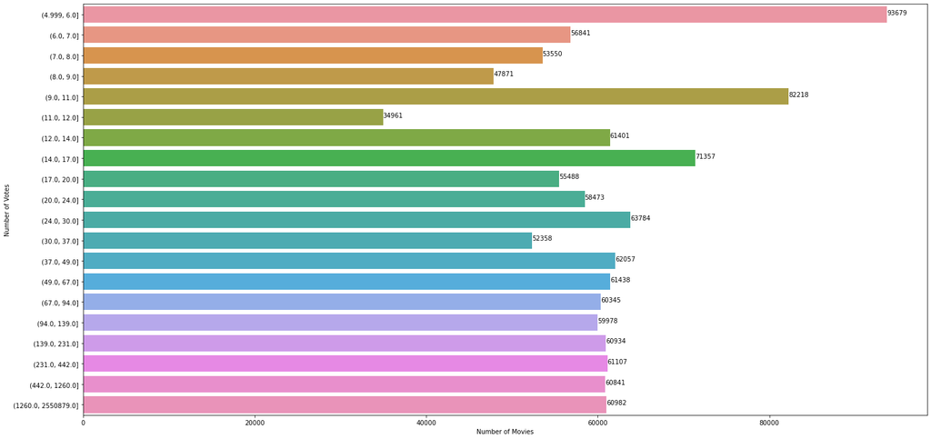

```python
buckets = 20
plt.figure(figsize=(24,12))
bins = pd.qcut(ratings.numVotes,buckets,duplicates="drop").value_counts()
p=sns.barplot(x=bins.values,y=bins.index,orient="h")
p.set_xlabel("Number of Movies")
p.set_ylabel("Number of Votes")
show_values(p,orient="h",space=.01,precision=0)
```

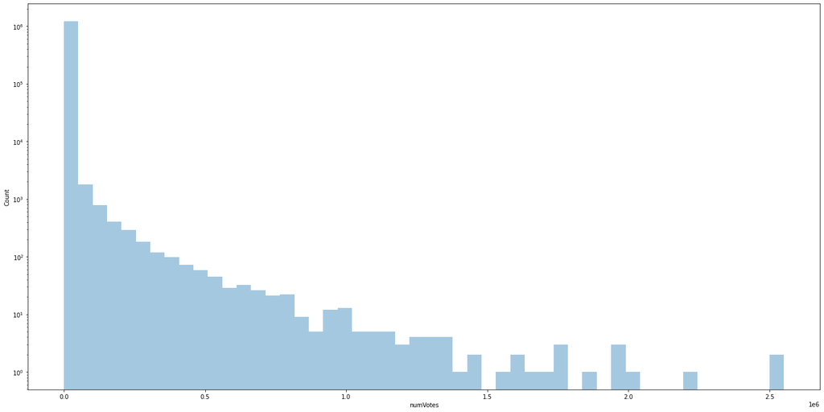

```python
plt.figure(figsize=(24,12))
ax=sns.distplot(ratings.numVotes,kde=False)
ax.set_ylabel("Count")
ax.set_yscale("log")
```

#### Counts per year

[figure not shown]

```python
merged_temp = pd.merge(ratings,basics,on="tconst",how="left")
merged_temp = merged_temp[(merged_temp.startYear.notnull())&(merged_temp.startYear<2022)]
counts_yearly = merged_temp.groupby("startYear").agg({"averageRating":[np.median],
                                                     "numVotes":[np.sum,np.size,lambda x: np.sum(x)/np.size(x)]})

max_count_year = int(counts_yearly[("numVotes","sum")].idxmax())
max_year = int(counts_yearly[("numVotes","size")].idxmax())

plt.figure(figsize=(24,12))

plt.subplot(1,2,1)
ax =counts_yearly[("numVotes","size")].plot()
ax.annotate("WW I",xy=(1914,counts_yearly[("numVotes","size")].loc[1914]), xytext=(1918,2000),
            arrowprops=dict(color="sandybrown",shrink=0.05,width=1))

ax.annotate("WW II",xy=(1939,counts_yearly[("numVotes","size")].loc[1939]), xytext=(1945,4000),
            arrowprops=dict(color="sandybrown",shrink=0.05,width=1))

ax.annotate(max_year,xy=(max_year,counts_yearly[("numVotes","size")].max()), xytext=(1980,10000),
            arrowprops=dict(color="sandybrown",shrink=0.05,width=1))

ax.annotate("COVID-19",xy=(2020,counts_yearly[("numVotes","size")].loc[2020]), xytext=(2020,4000),
            arrowprops=dict(color="sandybrown",shrink=0.05,width=1))

plt.title("Total Number Films per Year",fontweight="bold")



plt.subplot(1,2,2)
ax =counts_yearly[("numVotes","sum")].plot()
ax.annotate(max_count_year,xy=(max_count_year,counts_yearly[("numVotes","sum")].max()),
            xytext=(1960,4e7),arrowprops=dict(shrink=0.05,color="sandybrown",width=2))
plt.title("Total Number of Voters per Year",fontweight="bold")
plt.show()
```

#### Average per by year

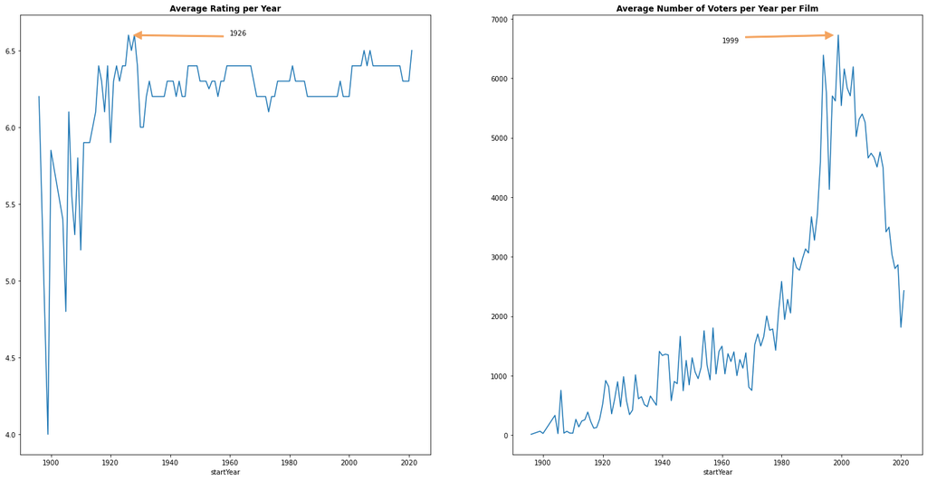

```python
max_count_year_per_film = int(counts_yearly[("numVotes","<lambda_0>")].idxmax())
max_rating_per_film = int(counts_yearly[("averageRating","median")].idxmax())

plt.figure(figsize=(24,12))

plt.subplot(1,2,1)
ax =counts_yearly[("averageRating","median")].plot()
ax.annotate(max_rating_per_film,xy=(max_rating_per_film,counts_yearly[("averageRating","median")].max()),
            xytext=(1960,6.6),arrowprops=dict(shrink=0.05,color="sandybrown",width=2))
plt.title("Average Rating per Year",fontweight="bold")

plt.subplot(1,2,2)
ax = counts_yearly[("numVotes","<lambda_0>")].plot()
ax.annotate(max_count_year_per_film,xy=(max_count_year_per_film,counts_yearly[("numVotes","<lambda_0>")].max()),
            xytext=(1960,6600),arrowprops=dict(shrink=0.05,color="sandybrown",width=2))
plt.title("Average Number of Voters per Year per Film",fontweight="bold")

plt.show()
```

```python
use = basics[basics.runtimeMinutes.notnull()]
use["runtimeMinutes"] = use.runtimeMinutes.astype(int)
use.sort_values(by="runtimeMinutes",ascending=False).head(10)
```

|  | tconst | titleType | primaryTitle | originalTitle | startYear | endYear | runtimeMinutes | genres |
| --- | --- | --- | --- | --- | --- | --- | --- | --- |
| 7975732 | tt8273150 | movie | Logistics | Logistics | 2012 | NaN | 51420 | Documentary |
| 5991910 | tt3854496 | movie | Ambiancé | Ambiancé | 2020 | NaN | 43200 | Documentary |
| 2236838 | tt12277054 | movie | Carnets Filmés (Liste Complète) | Carnets Filmés (Liste Complète) | 2019 | NaN | 28643 | Documentary |
| 5481874 | tt2659636 | movie | Modern Times Forever | Modern Times Forever | 2011 | NaN | 14400 | Documentary |
| 1439512 | tt10844900 | movie | Qw | Qw | 2019 | NaN | 10062 | Drama |
| 5334484 | tt2355497 | movie | Beijing 2003 | Beijing 2003 | 2004 | NaN | 9000 | Documentary |
| 4342099 | tt16226132 | movie | Soldier | Soldier | 2014 | NaN | 7200 | NaN |
| 6531504 | tt5068890 | movie | Hunger! | Hunger! | 2015 | NaN | 6000 | Documentary,Drama |
| 6561199 | tt5136218 | movie | London EC1 | London EC1 | 2015 | NaN | 5460 | Comedy,Drama,Mystery |
| 271971 | tt0284020 | movie | The Cure for Insomnia | The Cure for Insomnia | 1987 | NaN | 5220 | Documentary,Music |

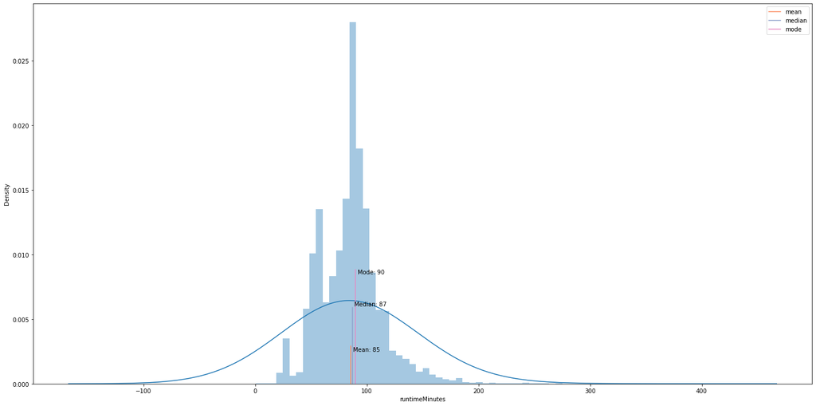

```python
rt = use.runtimeMinutes[use.runtimeMinutes<300]
mean_rt,median_rt,mode_rt = rt.mean(),rt.median(),rt.mode()[0]

plt.figure(figsize=(24,12))
sns.distplot(rt,kde_kws=dict(bw=2))
plt.gca().axvline(mean_rt,label="mean",color=sns.color_palette("Set2")[1],ymax=0.1)
plt.gca().axvline(median_rt,label="median",color=sns.color_palette("Set2")[2],ymax=0.2)
plt.gca().axvline(mode_rt,label="mode",color=sns.color_palette("Set2")[3],ymax=0.3)
plt.text(mean_rt+2,0.0025,f"Mean: {int(mean_rt)}")
plt.text(median_rt+2,0.006,f"Median: {int(median_rt)}")
plt.text(mode_rt+2,0.0085,f"Mode: {int(mode_rt)}")
plt.legend()
plt.show()
```

```python
# top 20 movies with the highest voter count

merged = pd.merge(ratings,basics,on="tconst",how="right").sort_values(by="numVotes",ascending=False)
merged[["numVotes","primaryTitle","startYear"]].iloc[:20,:]
```

|  | numVotes | primaryTitle | startYear |
| --- | --- | --- | --- |
| 73300 | 2550879.000 | The Shawshank Redemption | 1994 |
| 174884 | 2501585.000 | The Dark Knight | 2008 |
| 251667 | 2240118.000 | Inception | 2010 |
| 84913 | 2008263.000 | Fight Club | 1999 |
| 72326 | 1968554.000 | Forrest Gump | 1994 |
| 73105 | 1961407.000 | Pulp Fiction | 1994 |
| 83459 | 1839670.000 | The Matrix | 1999 |
| 79269 | 1779970.000 | The Lord of the Rings: The Fellowship of the Ring | 2001 |
| 93287 | 1758035.000 | The Lord of the Rings: The Return of the King | 2003 |
| 43448 | 1754988.000 | The Godfather | 1972 |
| 184849 | 1695889.000 | Interstellar | 2014 |
| 247357 | 1621375.000 | The Dark Knight Rises | 2012 |
| 93288 | 1588397.000 | The Lord of the Rings: The Two Towers | 2002 |
| 75258 | 1564190.000 | Se7en | 1995 |
| 302362 | 1474286.000 | Django Unchained | 2012 |
| 94948 | 1438015.000 | Gladiator | 2000 |
| 153970 | 1396121.000 | Batman Begins | 2005 |
| 151377 | 1375870.000 | Inglourious Basterds | 2009 |
| 67928 | 1369807.000 | The Silence of the Lambs | 1991 |
| 187230 | 1340919.000 | The Avengers | 2012 |

```python
# top 300 movies with the highest average rating

top300 = merged[merged.numVotes>25000].sort_values(by="averageRating",ascending=False).head(300)
```

```python
# bottom 20 movies with the lowest average rating

merged[merged.numVotes>25000].sort_values(by="averageRating",ascending=True).head(20)
```

|  | tconst | averageRating | numVotes | titleType | primaryTitle | originalTitle | startYear | endYear | runtimeMinutes | genres |
| --- | --- | --- | --- | --- | --- | --- | --- | --- | --- | --- |
| 424425 | tt7221896 | 1.000 | 38764.000 | movie | Cumali Ceber | Cumali Ceber: Allah Seni Alsin | 2017 | NaN | 100 | Comedy |
| 434233 | tt7886848 | 1.100 | 93845.000 | movie | Sadak 2 | Sadak 2 | 2020 | NaN | 133 | Action,Drama |
| 405480 | tt6038600 | 1.200 | 38549.000 | movie | Smolensk | Smolensk | 2016 | NaN | 120 | Drama,Thriller |
| 404565 | tt5988370 | 1.400 | 73215.000 | movie | Reis | Reis | 2017 | NaN | 108 | Biography,Drama |
| 265778 | tt14723224 | 1.500 | 37020.000 | movie | The Cost of Deception | Elk*rtuk | 2021 | NaN | 125 | Crime,Drama,History |
| 290614 | tt1702443 | 1.700 | 76204.000 | movie | Justin Bieber: Never Say Never | Justin Bieber: Never Say Never | 2011 | NaN | 105 | Documentary,Music |
| 209275 | tt10888594 | 1.800 | 175135.000 | movie | Radhe | Radhe | 2021 | NaN | 135 | Action,Crime,Thriller |
| 37474 | tt0060666 | 1.800 | 36034.000 | movie | Manos: The Hands of Fate | Manos: The Hands of Fate | 1966 | NaN | 70 | Horror |
| 183615 | tt0804492 | 1.900 | 38097.000 | movie | The Hottie & the Nottie | The Hottie & the Nottie | 2008 | NaN | 91 | Comedy,Romance |
| 427674 | tt7431594 | 1.900 | 45462.000 | movie | Race 3 | Race 3 | 2018 | NaN | 160 | Action,Crime,Thriller |
| 126193 | tt0270846 | 1.900 | 30873.000 | movie | Superbabies: Baby Geniuses 2 | Superbabies: Baby Geniuses 2 | 2004 | NaN | 88 | Comedy,Family,Sci-Fi |
| 227323 | tt1213644 | 1.900 | 90472.000 | movie | Disaster Movie | Disaster Movie | 2008 | NaN | 87 | Comedy,Sci-Fi |
| 374709 | tt4458206 | 2.000 | 27561.000 | movie | Code Name: K.O.Z. | Kod Adi K.O.Z. | 2015 | NaN | 114 | Crime,Mystery |
| 140415 | tt0317676 | 2.100 | 37061.000 | movie | House of the Dead | House of the Dead | 2003 | NaN | 90 | Action,Adventure,Horror |
| 146136 | tt0339034 | 2.100 | 26381.000 | movie | From Justin to Kelly | From Justin to Kelly | 2003 | NaN | 81 | Comedy,Musical,Romance |
| 151506 | tt0362165 | 2.200 | 55512.000 | movie | Son of the Mask | Son of the Mask | 2005 | NaN | 94 | Comedy,Family,Fantasy |
| 183344 | tt0799949 | 2.400 | 104754.000 | movie | Epic Movie | Epic Movie | 2007 | NaN | 86 | Adventure,Comedy,Fantasy |
| 332989 | tt2574698 | 2.400 | 58834.000 | movie | Gunday | Gunday | 2014 | NaN | 152 | Action,Drama,Musical |
| 200275 | tt10350922 | 2.400 | 56281.000 | movie | Laxmii | Laxmii | 2020 | NaN | 141 | Action,Comedy,Horror |
| 153177 | tt0369226 | 2.400 | 45345.000 | movie | Alone in the Dark | Alone in the Dark | 2005 | NaN | 99 | Action,Horror,Sci-Fi |

```python
# average rating average (median) by genre


merged_temp = merged[merged.genres.notnull()]
vec = CountVectorizer(token_pattern='(?u)\\b[\\w-]+\\b', analyzer='word').fit(merged_temp.genres)
bag_of_genres = pd.DataFrame(vec.transform(merged_temp.genres).todense(),
                             columns=vec.get_feature_names(),index=merged_temp.index)
merged_temp = pd.concat([merged_temp,bag_of_genres],axis=1)

rating_counts_means = pd.DataFrame([[merged_temp.averageRating[merged_temp[i]==1].median(),merged_temp[i].sum()]
 for i in vec.get_feature_names()],columns=["median","count"],index=vec.get_feature_names()).sort_values("median",ascending=False)

plt.figure(figsize=(7,8))
sns.barplot(y=rating_counts_means.index,x=rating_counts_means["median"],orient="h")
for i,counts in enumerate(rating_counts_means["count"]):
    plt.text(0.5,i+0.25,f"{counts:>5} films")
    plt.text(rating_counts_means["median"][i],i+0.25,rating_counts_means["median"][i])
plt.show()
```

[output not shown]

```python
# relation between rating and runtime

use = merged_temp[merged_temp.numVotes>1000]
use["runtimeMinutes"] = pd.to_numeric(use.runtimeMinutes)
[groups,edges] = pd.qcut(use.runtimeMinutes,10,precision=0,retbins=True)
ratings_avg = use.groupby(groups).agg({"averageRating":np.median})
sns.boxplot(y=groups,x="averageRating",data=use,orient="h",showfliers=False)
for i,rate in enumerate(ratings_avg["averageRating"]):
    plt.text(rate+0.1,i+0.2,rate)
plt.show()
```

[output not shown]

```python
df_movies = pd.merge( pd.merge(top300, principals, on='tconst'), name, on="nconst")
```

[output not shown]

```python
df_movies['birthYear'] = df_movies['birthYear'].astype(int, errors='ignore')
```

```python
df_movies.info()
```

```
<class 'pandas.core.frame.DataFrame'>
Int64Index: 2916 entries, 0 to 2915
Data columns (total 20 columns):
 #   Column             Non-Null Count  Dtype
---  ------             --------------  -----
 0   tconst             2916 non-null   object
 1   averageRating      2916 non-null   float64
 2   numVotes           2916 non-null   float64
 3   titleType          2916 non-null   object
 4   primaryTitle       2916 non-null   object
 5   originalTitle      2916 non-null   object
 6   startYear          2916 non-null   int32
 7   endYear            0 non-null      float64
 8   runtimeMinutes     2916 non-null   int32
 9   genres             2916 non-null   object
 10  ordering           2916 non-null   int64
 11  nconst             2916 non-null   object
 12  category           2916 non-null   object
 13  job                971 non-null    object
 14  characters         1181 non-null   object
 15  primaryName        2916 non-null   object
 16  birthYear          2246 non-null   float64
 17  deathYear          928 non-null    float64
 18  primaryProfession  2916 non-null   object
 19  knownForTitles     2914 non-null   object
dtypes: float64(5), int32(2), int64(1), object(12)
memory usage: 455.6+ KB
```

```python
df_movies.describe()
```

|  | averageRating | numVotes | startYear | endYear | runtimeMinutes | ordering | birthYear | deathYear |
| --- | --- | --- | --- | --- | --- | --- | --- | --- |
| count | 2916.000 | 2916.000 | 2916.000 | 0.000 | 2916.000 | 2916.000 | 2246.000 | 928.000 |
| mean | 8.329 | 459314.182 | 1990.041 | NaN | 131.821 | 5.465 | 1940.746 | 1988.816 |
| std | 0.242 | 513989.164 | 25.392 | NaN | 33.752 | 2.851 | 32.559 | 32.884 |
| min | 8.100 | 25076.000 | 1920.000 | NaN | 25.000 | 1.000 | 1414.000 | 1471.000 |
| 25% | 8.200 | 64873.000 | 1974.000 | NaN | 108.750 | 3.000 | 1921.000 | 1977.000 |
| 50% | 8.300 | 234502.000 | 1998.000 | NaN | 129.000 | 5.000 | 1944.000 | 1993.000 |
| 75% | 8.400 | 785304.000 | 2012.000 | NaN | 152.000 | 8.000 | 1964.000 | 2007.250 |
| max | 9.300 | 2550879.000 | 2021.000 | NaN | 321.000 | 10.000 | 2006.000 | 2022.000 |

```python
df_movies.head(100)
```

|  | tconst | averageRating | numVotes | titleType | primaryTitle | originalTitle | startYear | endYear | runtimeMinutes | genres | ordering | nconst | category | job | characters | primaryName | birthYear | deathYear | primaryProfession | knownForTitles |
| --- | --- | --- | --- | --- | --- | --- | --- | --- | --- | --- | --- | --- | --- | --- | --- | --- | --- | --- | --- | --- |
| 0 | tt0111161 | 9.300 | 2550879.000 | movie | The Shawshank Redemption | The Shawshank Redemption | 1994 | NaN | 142 | Drama | 10 | nm0290358 | editor | NaN | NaN | Richard Francis-Bruce | 1948.000 | NaN | editor,editorial_department,sound_department | tt0097162,tt0118571,tt0114369,tt0117500 |
| 1 | tt0114369 | 8.600 | 1564190.000 | movie | Se7en | Se7en | 1995 | NaN | 127 | Crime,Drama,Mystery | 10 | nm0290358 | editor | NaN | NaN | Richard Francis-Bruce | 1948.000 | NaN | editor,editorial_department,sound_department | tt0097162,tt0118571,tt0114369,tt0117500 |
| 2 | tt0120689 | 8.600 | 1240835.000 | movie | The Green Mile | The Green Mile | 1999 | NaN | 189 | Crime,Drama,Fantasy | 10 | nm0290358 | editor | NaN | NaN | Richard Francis-Bruce | 1948.000 | NaN | editor,editorial_department,sound_department | tt0097162,tt0118571,tt0114369,tt0117500 |
| 3 | tt0111161 | 9.300 | 2550879.000 | movie | The Shawshank Redemption | The Shawshank Redemption | 1994 | NaN | 142 | Drama | 1 | nm0000209 | actor | NaN | ["Andy Dufresne"] | Tim Robbins | 1958.000 | NaN | actor,producer,director | tt0327056,tt0111161,tt0091225,tt0105151 |
| 4 | tt0111161 | 9.300 | 2550879.000 | movie | The Shawshank Redemption | The Shawshank Redemption | 1994 | NaN | 142 | Drama | 2 | nm0000151 | actor | NaN | ["Ellis Boyd 'Red' Redding"] | Morgan Freeman | 1937.000 | NaN | actor,producer,soundtrack | tt0468569,tt0405159,tt0114369,tt1057500 |
| 5 | tt0114369 | 8.600 | 1564190.000 | movie | Se7en | Se7en | 1995 | NaN | 127 | Crime,Drama,Mystery | 1 | nm0000151 | actor | NaN | ["Somerset"] | Morgan Freeman | 1937.000 | NaN | actor,producer,soundtrack | tt0468569,tt0405159,tt0114369,tt1057500 |
| 6 | tt0105695 | 8.200 | 400346.000 | movie | Unforgiven | Unforgiven | 1992 | NaN | 130 | Drama,Western | 3 | nm0000151 | actor | NaN | ["Ned Logan"] | Morgan Freeman | 1937.000 | NaN | actor,producer,soundtrack | tt0468569,tt0405159,tt0114369,tt1057500 |
| 7 | tt0111161 | 9.300 | 2550879.000 | movie | The Shawshank Redemption | The Shawshank Redemption | 1994 | NaN | 142 | Drama | 3 | nm0348409 | actor | NaN | ["Warden Norton"] | Bob Gunton | 1945.000 | NaN | actor,soundtrack | tt0111161,tt0285331,tt3305388,tt3322312 |
| 8 | tt0111161 | 9.300 | 2550879.000 | movie | The Shawshank Redemption | The Shawshank Redemption | 1994 | NaN | 142 | Drama | 4 | nm0006669 | actor | NaN | ["Heywood"] | William Sadler | 1950.000 | NaN | actor,soundtrack,director | tt0884328,tt0099423,tt0111161,tt0101452 |
| 9 | tt0111161 | 9.300 | 2550879.000 | movie | The Shawshank Redemption | The Shawshank Redemption | 1994 | NaN | 142 | Drama | 5 | nm0001104 | director | NaN | NaN | Frank Darabont | 1959.000 | NaN | writer,producer,director | tt1520211,tt0884328,tt0120689,tt0111161 |
| 10 | tt0120689 | 8.600 | 1240835.000 | movie | The Green Mile | The Green Mile | 1999 | NaN | 189 | Crime,Drama,Fantasy | 5 | nm0001104 | director | NaN | NaN | Frank Darabont | 1959.000 | NaN | writer,producer,director | tt1520211,tt0884328,tt0120689,tt0111161 |
| 11 | tt0111161 | 9.300 | 2550879.000 | movie | The Shawshank Redemption | The Shawshank Redemption | 1994 | NaN | 142 | Drama | 6 | nm0000175 | writer | based on the short novel "Rita Hayworth and th... | NaN | Stephen King | 1947.000 | NaN | writer,producer,actor | tt0083767,tt0324864,tt0091499,tt0111161 |
| 12 | tt0120689 | 8.600 | 1240835.000 | movie | The Green Mile | The Green Mile | 1999 | NaN | 189 | Crime,Drama,Fantasy | 6 | nm0000175 | writer | novel | NaN | Stephen King | 1947.000 | NaN | writer,producer,actor | tt0083767,tt0324864,tt0091499,tt0111161 |
| 13 | tt0081505 | 8.400 | 972909.000 | movie | The Shining | The Shining | 1980 | NaN | 146 | Drama,Horror | 6 | nm0000175 | writer | based upon the novel by | NaN | Stephen King | 1947.000 | NaN | writer,producer,actor | tt0083767,tt0324864,tt0091499,tt0111161 |
| 14 | tt0092005 | 8.100 | 389015.000 | movie | Stand by Me | Stand by Me | 1986 | NaN | 89 | Adventure,Drama | 6 | nm0000175 | writer | novella "The Body" | NaN | Stephen King | 1947.000 | NaN | writer,producer,actor | tt0083767,tt0324864,tt0091499,tt0111161 |
| 15 | tt0111161 | 9.300 | 2550879.000 | movie | The Shawshank Redemption | The Shawshank Redemption | 1994 | NaN | 142 | Drama | 7 | nm0555550 | producer | producer | NaN | Niki Marvin | NaN | NaN | producer,director,writer | tt0100146,tt0111161,tt4337004,tt0093629 |
| 16 | tt0111161 | 9.300 | 2550879.000 | movie | The Shawshank Redemption | The Shawshank Redemption | 1994 | NaN | 142 | Drama | 8 | nm0002353 | composer | NaN | NaN | Thomas Newman | 1955.000 | NaN | music_department,composer,soundtrack | tt1074638,tt0910970,tt8579674,tt0169547 |
| 17 | tt0120689 | 8.600 | 1240835.000 | movie | The Green Mile | The Green Mile | 1999 | NaN | 189 | Crime,Drama,Fantasy | 8 | nm0002353 | composer | NaN | NaN | Thomas Newman | 1955.000 | NaN | music_department,composer,soundtrack | tt1074638,tt0910970,tt8579674,tt0169547 |
| 18 | tt0910970 | 8.400 | 1071208.000 | movie | WALL·E | WALL·E | 2008 | NaN | 98 | Adventure,Animation,Family | 9 | nm0002353 | composer | NaN | NaN | Thomas Newman | 1955.000 | NaN | music_department,composer,soundtrack | tt1074638,tt0910970,tt8579674,tt0169547 |
| 19 | tt0169547 | 8.300 | 1123772.000 | movie | American Beauty | American Beauty | 1999 | NaN | 122 | Drama | 9 | nm0002353 | composer | NaN | NaN | Thomas Newman | 1955.000 | NaN | music_department,composer,soundtrack | tt1074638,tt0910970,tt8579674,tt0169547 |
| 20 | tt0266543 | 8.100 | 1006919.000 | movie | Finding Nemo | Finding Nemo | 2003 | NaN | 100 | Adventure,Animation,Comedy | 10 | nm0002353 | composer | NaN | NaN | Thomas Newman | 1955.000 | NaN | music_department,composer,soundtrack | tt1074638,tt0910970,tt8579674,tt0169547 |
| 21 | tt0111161 | 9.300 | 2550879.000 | movie | The Shawshank Redemption | The Shawshank Redemption | 1994 | NaN | 142 | Drama | 9 | nm0005683 | cinematographer | director of photography | NaN | Roger Deakins | 1949.000 | NaN | cinematographer,camera_department,miscellaneous | tt0477348,tt1074638,tt1856101,tt8579674 |
| 22 | tt0268978 | 8.200 | 901477.000 | movie | A Beautiful Mind | A Beautiful Mind | 2001 | NaN | 135 | Biography,Drama | 10 | nm0005683 | cinematographer | director of photography | NaN | Roger Deakins | 1949.000 | NaN | cinematographer,camera_department,miscellaneous | tt0477348,tt1074638,tt1856101,tt8579674 |
| 23 | tt0118715 | 8.100 | 783479.000 | movie | The Big Lebowski | The Big Lebowski | 1998 | NaN | 117 | Comedy,Crime | 8 | nm0005683 | cinematographer | director of photography | NaN | Roger Deakins | 1949.000 | NaN | cinematographer,camera_department,miscellaneous | tt0477348,tt1074638,tt1856101,tt8579674 |
| 24 | tt0477348 | 8.100 | 929545.000 | movie | No Country for Old Men | No Country for Old Men | 2007 | NaN | 122 | Crime,Drama,Thriller | 10 | nm0005683 | cinematographer | director of photography | NaN | Roger Deakins | 1949.000 | NaN | cinematographer,camera_department,miscellaneous | tt0477348,tt1074638,tt1856101,tt8579674 |
| 25 | tt15097216 | 9.300 | 175864.000 | movie | Jai Bhim | Jai Bhim | 2021 | NaN | 164 | Crime,Drama,Mystery | 1 | nm1421814 | actor | NaN | ["Chandru"] | Suriya | 1975.000 | NaN | actor,producer,music_department | tt4981966,tt1725795,tt15097216,tt10189514 |
| 26 | tt10189514 | 9.100 | 107744.000 | movie | Soorarai Pottru | Soorarai Pottru | 2020 | NaN | 153 | Drama | 1 | nm1421814 | actor | NaN | ["Nedumaaran Rajangam"] | Suriya | 1975.000 | NaN | actor,producer,music_department | tt4981966,tt1725795,tt15097216,tt10189514 |
| 27 | tt15097216 | 9.300 | 175864.000 | movie | Jai Bhim | Jai Bhim | 2021 | NaN | 164 | Crime,Drama,Mystery | 2 | nm7934649 | actress | NaN | ["Senggeni"] | Lijo Mol Jose | NaN | NaN | actress | tt10334602,tt5598764,tt4851630,tt15097216 |
| 28 | tt15097216 | 9.300 | 175864.000 | movie | Jai Bhim | Jai Bhim | 2021 | NaN | 164 | Crime,Drama,Mystery | 3 | nm8904193 | actor | NaN | ["Rajakannu"] | Manikandan K. | NaN | NaN | actor,writer,director | tt6148156,tt15097216,tt10468636,tt17508126 |
| 29 | tt6148156 | 8.300 | 36129.000 | movie | Vikram Vedha | Vikram Vedha | 2017 | NaN | 147 | Action,Crime,Drama | 7 | nm8904193 | writer | dialogue by | NaN | Manikandan K. | NaN | NaN | actor,writer,director | tt6148156,tt15097216,tt10468636,tt17508126 |

[output cut: 70 more lines]

```python
df_movie_director = df_movies[df_movies.category=="director"]
```

```python
df_movie_director = df_movie_director.drop(['category','job','characters','endYear','titleType','ordering'],axis=1)
```

```python
df_movie_director[df_movie_director.birthYear.isnull()]
```

|  | tconst | averageRating | numVotes | primaryTitle | originalTitle | startYear | runtimeMinutes | genres | nconst | primaryName | birthYear | deathYear | primaryProfession | knownForTitles |
| --- | --- | --- | --- | --- | --- | --- | --- | --- | --- | --- | --- | --- | --- | --- |
| 31 | tt15097216 | 9.300 | 175864.000 | Jai Bhim | Jai Bhim | 2021 | 164 | Crime,Drama,Mystery | nm4377096 | T.J. Gnanavel | NaN | NaN | writer,director | tt2217781,tt6278350,tt1836883,tt15097216 |
| 75 | tt10189514 | 9.100 | 107744.000 | Soorarai Pottru | Soorarai Pottru | 2020 | 153 | Drama | nm1464314 | Sudha Kongara | NaN | NaN | writer,director,assistant_director | tt6010240,tt13206988,tt5310090,tt10189514 |
| 85 | tt5354160 | 9.100 | 25645.000 | Mirror Game | Aynabaji | 2016 | 147 | Crime,Mystery,Thriller | nm2755490 | Amitabh Reza Chowdhury | NaN | NaN | director,miscellaneous,actor | tt5354160,tt4853244,tt10173814,tt6974890 |
| 92 | tt2592910 | 9.100 | 45703.000 | CM101MMXI Fundamentals | CM101MMXI Fundamentals | 2013 | 139 | Comedy,Documentary | nm2339782 | Murat Dündar | NaN | NaN | assistant_director,director | tt3698408,tt0384116,tt0827503,tt6697582 |
| 163 | tt11989890 | 9.000 | 30779.000 | David Attenborough: A Life on Our Planet | David Attenborough: A Life on Our Planet | 2020 | 83 | Biography,Documentary | nm1649287 | Jonathan Hughes | NaN | NaN | producer,director,miscellaneous | tt1705039,tt11989890,tt1160199,tt1647936 |
| 164 | tt11989890 | 9.000 | 30779.000 | David Attenborough: A Life on Our Planet | David Attenborough: A Life on Our Planet | 2020 | 83 | Biography,Documentary | nm0774582 | Keith Scholey | NaN | NaN | producer,director,writer | tt12100080,tt1223236,tt11989890,tt9253866 |
| 378 | tt10280296 | 8.700 | 36579.000 | Sardar Udham | Sardar Udham | 2021 | 164 | Biography,Crime,Drama | nm1999473 | Shoojit Sircar | NaN | NaN | director,producer,actor | tt3767372,tt2317337,tt10280296,tt5571734 |
| 398 | tt5813916 | 8.700 | 107606.000 | The Mountain II | Dag II | 2016 | 135 | Action,Drama,War | nm3809021 | Alper Caglar | NaN | NaN | producer,writer,editor | tt2471640,tt7158912,tt5813916,tt3345952 |
| 440 | tt10295212 | 8.700 | 113506.000 | Shershaah | Shershaah | 2021 | 135 | Action,Biography,Drama | nm3315387 | Vishnuvardhan | NaN | NaN | writer,director,actor | tt2091384,tt2555958,tt10295212,tt4328890 |
| 465 | tt9477520 | 8.600 | 25350.000 | Asuran | Asuran | 2019 | 141 | Action,Drama | nm4274575 | Vetrimaaran | NaN | NaN | writer,director,producer | tt4991384,tt5959980,tt9477520,tt1821317 |
| 597 | tt0103767 | 8.600 | 38286.000 | Baraka | Baraka | 1992 | 96 | Documentary | nm0294825 | Ron Fricke | NaN | NaN | cinematographer,camera_department,writer | tt0088919,tt0103767,tt0121766,tt0770802 |
| 598 | tt0770802 | 8.500 | 35253.000 | Samsara | Samsara | 2011 | 102 | Documentary,Music | nm0294825 | Ron Fricke | NaN | NaN | cinematographer,camera_department,writer | tt0088919,tt0103767,tt0121766,tt0770802 |
| 771 | tt7019842 | 8.500 | 27776.000 | 96 | 96 | 2018 | 158 | Drama,Romance | nm4242320 | C. Prem Kumar | NaN | NaN | cinematographer,director,writer | tt7019842,tt2564144,tt2946508,tt9691336 |
| 956 | tt2380307 | 8.400 | 464501.000 | Coco | Coco | 2017 | 105 | Adventure,Animation,Comedy | nm2937122 | Adrian Molina | NaN | NaN | miscellaneous,writer,animation_department | tt0382932,tt1453405,tt1979388,tt2380307 |
| 998 | tt4633694 | 8.400 | 473115.000 | Spider-Man: Into the Spider-Verse | Spider-Man: Into the Spider-Verse | 2018 | 117 | Action,Adventure,Animation | nm2130108 | Bob Persichetti | NaN | NaN | animation_department,art_department,director | tt4633694,tt0298148,tt0448694,tt1754656 |
| 1000 | tt4633694 | 8.400 | 473115.000 | Spider-Man: Into the Spider-Verse | Spider-Man: Into the Spider-Verse | 2018 | 117 | Action,Adventure,Animation | nm0745247 | Rodney Rothman | NaN | NaN | writer,producer,director | tt4633694,tt0800039,tt2294449,tt3960412 |
| 1023 | tt7060344 | 8.400 | 38104.000 | Raatchasan | Ratsasan | 2018 | 170 | Crime,Drama,Mystery | nm6442107 | Ram Kumar | NaN | NaN | writer,director,actor | tt3681442,tt10133300,tt7060344,tt15768004 |
| 1035 | tt6316138 | 8.400 | 38320.000 | Ayla: The Daughter of War | Ayla: The Daughter of War | 2017 | 125 | Biography,Drama,History | nm7073474 | Halenur Uzunoglu | NaN | NaN | director,assistant_director,writer | tt4745726,tt6316138,tt3371332,tt7668842 |
| 1108 | tt5074352 | 8.400 | 178804.000 | Dangal | Dangal | 2016 | 161 | Action,Biography,Drama | nm4318159 | Nitesh Tiwari | NaN | NaN | writer,director,producer | tt3531852,tt5074352,tt6967980,tt9052870 |
| 1109 | tt9052870 | 8.300 | 47975.000 | Chhichhore | Chhichhore | 2019 | 143 | Comedy,Drama,Romance | nm4318159 | Nitesh Tiwari | NaN | NaN | writer,director,producer | tt3531852,tt5074352,tt6967980,tt9052870 |
| 1146 | tt0986264 | 8.400 | 186044.000 | Like Stars on Earth | Taare Zameen Par | 2007 | 165 | Drama,Family | nm1244760 | Amole Gupte | NaN | NaN | actor,writer,director | tt1274295,tt7291466,tt0986264,tt1907761 |
| 1210 | tt8503618 | 8.400 | 83509.000 | Hamilton | Hamilton | 2020 | 160 | Biography,Drama,History | nm2371802 | Thomas Kail | NaN | NaN | director,producer,writer | tt8746478,tt8503618,tt4366830,tt12408644 |
| 1319 | tt6148156 | 8.300 | 36129.000 | Vikram Vedha | Vikram Vedha | 2017 | 147 | Action,Crime,Drama | nm2566836 | Gayatri | NaN | NaN | director,writer,costume_designer | tt0977625,tt6148156,tt13131350,tt1735932 |
| 1320 | tt6148156 | 8.300 | 36129.000 | Vikram Vedha | Vikram Vedha | 2017 | 147 | Action,Crime,Drama | nm2575525 | Pushkar | NaN | NaN | director,writer,producer | tt13131350,tt6148156,tt1735932,tt0977625 |
| 1436 | tt8291224 | 8.300 | 55537.000 | Uri: The Surgical Strike | Uri: The Surgical Strike | 2019 | 138 | Action,Drama,War | nm2336554 | Aditya Dhar | NaN | NaN | writer,music_department,soundtrack | tt1708453,tt11069946,tt8291224,tt1706317 |
| 1459 | tt7838252 | 8.300 | 55527.000 | K.G.F: Chapter 1 | K.G.F: Chapter 1 | 2018 | 156 | Action,Crime,Drama | nm6073824 | Prashanth Neel | NaN | NaN | writer,director | tt13927994,tt7838252,tt10698680,tt3320542 |
| 1471 | tt11032374 | 8.300 | 49187.000 | Demon Slayer the Movie: Mugen Train | Kimetsu no Yaiba: Mugen Ressha-Hen | 2020 | 117 | Action,Adventure,Animation | nm1417038 | Haruo Sotozaki | NaN | NaN | animation_department,director,art_department | tt0275277,tt11032374,tt14888874,tt9335498 |
| 1540 | tt8239946 | 8.300 | 40102.000 | Tumbbad | Tumbbad | 2018 | 104 | Drama,Fantasy,Horror | nm9751348 | Rahi Anil Barve | NaN | NaN | director,writer | tt8239946,tt15671624,tt15671606 |
| 1542 | tt8239946 | 8.300 | 40102.000 | Tumbbad | Tumbbad | 2018 | 104 | Drama,Fantasy,Horror | nm4205110 | Adesh Prasad | NaN | NaN | assistant_director,editorial_department,director | tt8239946,tt1772332,tt1608777,tt1773764 |
| 1701 | tt0110057 | 8.300 | 25982.000 | Hoop Dreams | Hoop Dreams | 1994 | 170 | Documentary,Drama,Sport | nm0416945 | Steve James | NaN | NaN | director,producer,editor | tt2382298,tt5952382,tt1319744,tt0334416 |
| 1716 | tt1620933 | 8.200 | 35599.000 | Paan Singh Tomar | Paan Singh Tomar | 2012 | 135 | Action,Biography,Crime | nm0223606 | Tigmanshu Dhulia | NaN | NaN | director,actor,writer | tt1620933,tt2073070,tt2362778,tt1954470 |
| 1752 | tt8108198 | 8.200 | 87799.000 | Andhadhun | Andhadhun | 2018 | 139 | Comedy,Crime,Music | nm1437189 | Sriram Raghavan | NaN | NaN | writer,director | tt0352314,tt1077248,tt3678782,tt8108198 |
| 1759 | tt2375605 | 8.200 | 37414.000 | The Act of Killing | The Act of Killing | 2012 | 117 | Biography,Crime,Documentary | nm5256112 | Anonymous | NaN | NaN | producer,miscellaneous,camera_department | tt0795174,tt2375605,tt3521134 |
| 1760 | tt2375605 | 8.200 | 37414.000 | The Act of Killing | The Act of Killing | 2012 | 117 | Biography,Crime,Documentary | nm2964327 | Christine Cynn | NaN | NaN | producer,director,camera_department | tt2375605,tt5749684,tt0407827,tt0795174 |
| 1913 | tt4635372 | 8.200 | 27065.000 | Masaan | Masaan | 2015 | 109 | Drama | nm4784536 | Neeraj Ghaywan | NaN | NaN | director,writer,assistant_director | tt1954470,tt7695134,tt4635372,tt6077448 |
| 1919 | tt0871510 | 8.200 | 78565.000 | Let's Go! India | Chak De! India | 2007 | 153 | Drama,Family,Sport | nm0024912 | Shimit Amin | NaN | NaN | editorial_department,sound_department,director | tt0341266,tt0402014,tt0133189,tt0871510 |
| 1991 | tt7775622 | 8.200 | 64071.000 | Free Solo | Free Solo | 2018 | 100 | Adventure,Documentary,Sport | nm1888091 | Elizabeth Chai Vasarhelyi | NaN | NaN | director,producer,writer | tt2545428,tt7775622,tt1235450,tt9098872 |
| 2000 | tt0242519 | 8.200 | 64213.000 | Hera Pheri | Hera Pheri | 2000 | 156 | Action,Comedy,Crime | nm0698184 | Priyadarshan | NaN | NaN | director,writer,actor | tt0255289,tt1286811,tt8345300,tt5548032 |
| 2057 | tt10431500 | 8.200 | 46020.000 | Miracle in Cell No. 7 | Yedinci Kogustaki Mucize | 2019 | 132 | Drama | nm3133017 | Mehmet Ada Öztekin | NaN | NaN | director,writer,assistant_director | tt2736928,tt13161356,tt10431500,tt1808223 |
| 2326 | tt4729430 | 8.200 | 138862.000 | Klaus | Klaus | 2019 | 96 | Adventure,Animation,Comedy | nm0655053 | Sergio Pablos | NaN | NaN | animation_department,writer,producer | tt4729430,tt0133240,tt1323594,tt1436562 |
| 2327 | tt4729430 | 8.200 | 138862.000 | Klaus | Klaus | 2019 | 96 | Adventure,Animation,Comedy | nm3582089 | Carlos Martínez López | NaN | NaN | visual_effects,director,animation_department | tt2857458,tt0762125,tt4729430,tt3896100 |
| 2348 | tt4934950 | 8.200 | 34277.000 | Talvar | Talvar | 2015 | 132 | Crime,Drama,Mystery | nm1126068 | Meghna Gulzar | NaN | NaN | writer,director,assistant_director | tt4430212,tt4934950,tt9614460,tt7098658 |
| 2350 | tt3390572 | 8.100 | 53082.000 | Haider | Haider | 2014 | 160 | Action,Crime,Drama | nm0080235 | Vishal Bhardwaj | NaN | NaN | composer,writer,soundtrack | tt3390572,tt4934950,tt0488414,tt0379370 |
| 2371 | tt2283748 | 8.100 | 56665.000 | OMG: Oh My God! | OMG: Oh My God! | 2012 | 125 | Comedy,Drama,Fantasy | nm1084488 | Umesh Shukla | NaN | NaN | writer,actor,director | tt10681556,tt2283748,tt1391544,tt3547616 |
| 2437 | tt0434409 | 8.100 | 1089704.000 | V for Vendetta | V for Vendetta | 2005 | 132 | Action,Drama,Sci-Fi | nm0574625 | James McTeigue | NaN | NaN | director,assistant_director,producer | tt0434409,tt1486192,tt0133093,tt3247714 |
| 2513 | tt2545118 | 8.100 | 65668.000 | Blackfish | Blackfish | 2013 | 83 | Documentary | nm1363250 | Gabriela Cowperthwaite | NaN | NaN | producer,director,writer | tt9608818,tt2545118 |
| 2590 | tt0384116 | 8.100 | 61248.000 | G.O.R.A. | G.O.R.A. | 2004 | 127 | Adventure,Comedy,Sci-Fi | nm0814716 | Ömer Faruk Sorak | NaN | NaN | director,production_designer,producer | tt0270053,tt0384116,tt1567448,tt0826631 |
| 2735 | tt0200087 | 8.100 | 25262.000 | Sarfarosh | Sarfarosh | 1999 | 174 | Action,Drama,Thriller | nm0559877 | John Mathew Matthan | NaN | NaN | director,writer,assistant_director | tt0925058,tt0475627,tt0200087,tt0083987 |
| 2852 | tt8110330 | 8.100 | 126894.000 | Dil Bechara | Dil Bechara | 2020 | 101 | Comedy,Drama,Romance | nm2535507 | Mukesh Chhabra | NaN | NaN | casting_director,casting_department,actor | tt3390572,tt5460276,tt2112124,tt8110330 |
| 2902 | tt2948372 | 8.100 | 300721.000 | Soul | Soul | 2020 | 100 | Adventure,Animation,Comedy | nm5358492 | Kemp Powers | NaN | NaN | writer,director,actor | tt5171438,tt2948372,tt16360004,tt10612922 |

```python
df_movie_director.to_csv("../02DerivedData/movie_director.csv",index=False)
```

# MetaCritic

```python
mc_movie = pd.read_csv('../01PrimaryData/MetaCritic/movies.csv')
mc_movie.head()
```

|  | movie_title | release_date | genre | meta_mixed | meta_negative | meta_positive | metascore | user_mixed | user_negative | user_positive | userscore |
| --- | --- | --- | --- | --- | --- | --- | --- | --- | --- | --- | --- |
| 0 | Anatomy of a Murder | 1-Jul-59 | Drama,Mystery,Thriller,Crime | 0 | 0 | 15 | 95 | 0 | 0 | 3 | tbd |
| 1 | Bringing Up Baby | 18-Feb-38 | Comedy,Romance,Family | 0 | 1 | 16 | 91 | 1 | 0 | 2 | tbd |
| 2 | After Life | 12-May-99 | Drama,Fantasy | 0 | 0 | 19 | 91 | 0 | 2 | 1 | tbd |
| 3 | Gavagai | 3-Aug-18 | Drama | 1 | 0 | 6 | 91 | 0 | 1 | 2 | tbd |
| 4 | The Hustler | 25-Sep-61 | Drama,Sport | 1 | 0 | 17 | 90 | 0 | 0 | 3 | tbd |

```python
mc_review = pd.read_csv('../01PrimaryData/MetaCritic/reviews.csv')
mc_review.head()
```

|  | critic_name | media | movie_title | review_date | individual_meta_score | text |
| --- | --- | --- | --- | --- | --- | --- |
| 0 | M. E. Russell | Portland Oregonian | Hustle & Flow | NaN | 100 | The writing, acting and filmmaking make Hustle... |
| 1 | Owen Gleiberman | Entertainment Weekly | Hustle & Flow | NaN | 91 | The home-studio recording sequences in Hustle ... |
| 2 | Ann Hornaday | Washington Post | Hustle & Flow | NaN | 90 | The performances are accomplished, but the rea... |
| 3 | Stephanie Zacharek | Salon | Hustle & Flow | NaN | 90 | In a world of movies that try far too hard to ... |
| 4 | Jami Bernard | New York Daily News | Hustle & Flow | NaN | 88 | The feel-good movie of the summer. And the son... |

```python
mc_review.describe(include='all')
```

|  | critic_name | media | movie_title | review_date | individual_meta_score | text |
| --- | --- | --- | --- | --- | --- | --- |
| count | 213860 | 232245 | 246955 | 105710 | 246.955k | 233198 |
| unique | 1006 | 77 | 12029 | 3096 | NaN | 232965 |
| top | Roger Ebert | The New York Times | The Lion King | 29-Jun-17 | NaN | One of the best films of the year. |
| freq | 4763 | 11742 | 83 | 194 | NaN | 10 |
| mean | NaN | NaN | NaN | NaN | 62.579 | NaN |
| std | NaN | NaN | NaN | NaN | 21.121 | NaN |
| min | NaN | NaN | NaN | NaN | 0.000 | NaN |
| 25% | NaN | NaN | NaN | NaN | 50.000 | NaN |
| 50% | NaN | NaN | NaN | NaN | 63.000 | NaN |
| 75% | NaN | NaN | NaN | NaN | 80.000 | NaN |
| max | NaN | NaN | NaN | NaN | 100.000 | NaN |

# MovieLens

```python
import os
import random
import zipfile
import re
import math
import urllib


# essentials
import numpy as np
import pandas as pd
import tensorflow as tf


#viz
import matplotlib.pyplot as plt
import seaborn as sb
from sklearn.manifold import TSNE
from tqdm import tqdm_notebook

# import our skipgram model from local
#from skip_gram_model import SkipGramModel
```

```python
import math
import tensorflow.compat.v1 as tf
tf.disable_v2_behavior()


class SkipGramModel(object):

    """Word2Vec ( Mikolov et al.) using skipgram model. Can be used on non-word text
    inputs too!

    Attributes:
        b (tf.Variable): bias for nce loss
        batch_size (int): size of training batch
        embedding_dims (int): size of embedding
        embeddings (tf.Variable): embedding object for text/items
        init_op (tf.global_variables_initializer): this is tf.global_variables_initializer
            to initilize variable in the model. call as model.init_op() in session.
        loss (TYPE): model loss function - mean NCE loss
        lr (TYPE): learning rate passed to optimizer
        n_samples (int): number of negative samples based on batch size and
            the sample_factor parameter.
        normalized_embeddings (tensor): normalized embeddings
        optimize (tensor): optimization step
        optimizer (tf.train.Optimizer): optimizer default is adagrad
        saver (tf.train.Saver): tf.train.Saver object call in session after model.init_op().
        similarity (tensor): measure similarity on val_x
        val_data (np.array, 'int32'): indexes of validation samples to evaluate similarity on during training
        val_x (tf.Placeholder): from val_data
        vocab_size (int): size of 'vocabulary'
        w (tf.Variable): weights for nce loss
        x (tf.Placeholder): placeholder for input data
        y (tf.Placeholder): placeholder for input labels
    """

    def __init__(self, vocab_size, val_data, embedding_dims=256, batch_size=128, sample_factor=1, lr=1., optimizer=tf.train.AdagradOptimizer):

        self.embedding_dims = embedding_dims
        self.vocab_size = vocab_size
        self.batch_size = batch_size
        self.optimizer = optimizer
        self.val_data = val_data


        #number of negative samples (batch * sample factors)
        self.n_samples = int(round(sample_factor  * self.batch_size))
        self.lr = lr
        self.init_model()

    @staticmethod
    def embed(embeddings, inp):
        return tf.nn.embedding_lookup(embeddings, inp)

    def mean_nce_loss(self, inp):
        return tf.reduce_mean(tf.nn.nce_loss(weights=self.w,
                                                 biases=self.b,
                                                 labels=self.y,
                                                 inputs=inp,
                                                 num_sampled=self.n_samples,
                                                 num_classes=self.vocab_size), name='loss')

    def normalize_embeddings(self):
        norm = tf.sqrt(tf.reduce_sum(tf.square(self.embeddings), 1, keep_dims=True))
        normalized_embeddings = self.embeddings / norm
        self.normalized_embeddings = normalized_embeddings

    def get_similarity(self, t):
        pred_embeddings = self.embed(self.normalized_embeddings, t)
        sim = tf.matmul(pred_embeddings, self.normalized_embeddings, transpose_b=True)
        return sim


    def init_model(self):
        # Input data.
        self.x = tf.placeholder(tf.int32, shape=[self.batch_size], name='x')
        self.y = tf.placeholder(tf.int32, shape=[self.batch_size, 1], name='y')
        self.val_x = tf.constant(self.val_data, name='val_x')
        # embedding var

        with tf.device('/cpu:0'):
            self.embeddings = tf.Variable(tf.random_uniform([self.vocab_size, self.embedding_dims], -1.0, 1.0))
            # nce loss weights and biases
            self.w = tf.Variable(tf.truncated_normal([self.vocab_size, self.embedding_dims],
                                                    stddev=1.0 / math.sqrt(self.embedding_dims)))
            self.b = tf.Variable(tf.zeros([self.vocab_size]))

        embedded = self.embed(self.embeddings, self.x)
        self.loss = self.mean_nce_loss(embedded)
        self.optimize = self.optimizer(self.lr).minimize(self.loss, name='optimize')

        self.normalize_embeddings()
        self.similarity = self.get_similarity(self.val_x)
        self.init_op = tf.global_variables_initializer
        self.saver = tf.train.Saver
```

```python
data_dir = '../01PrimaryData/MovieLens/'
ml_ratings = pd.read_csv(os.path.join(data_dir, 'ratings.csv'))
ml_movies = pd.read_csv(os.path.join(data_dir, 'movies.csv'))
```

```python
ml_movies.head()
```

|  | movieId | title | genres |
| --- | --- | --- | --- |
| 0 | 1 | Toy Story (1995) | Adventure\|Animation\|Children\|Comedy\|Fantasy |
| 1 | 2 | Jumanji (1995) | Adventure\|Children\|Fantasy |
| 2 | 3 | Grumpier Old Men (1995) | Comedy\|Romance |
| 3 | 4 | Waiting to Exhale (1995) | Comedy\|Drama\|Romance |
| 4 | 5 | Father of the Bride Part II (1995) | Comedy |

```python
ml_ratings.head()
```

|  | userId | movieId | rating | timestamp |
| --- | --- | --- | --- | --- |
| 0 | 1 | 2 | 3.5 | 1112486027 |
| 1 | 1 | 29 | 3.5 | 1112484676 |
| 2 | 1 | 32 | 3.5 | 1112484819 |
| 3 | 1 | 47 | 3.5 | 1112484727 |
| 4 | 1 | 50 | 3.5 | 1112484580 |

```python
counts = ml_ratings.movieId.value_counts()

# filter out movies only in dataset once
ratings = ml_ratings.loc[ml_ratings.movieId.isin(counts.loc[(counts > 1)].index)]
```

```python
# repalce movieId with an integer for its frequency
# make a dictionary of old_id2 moviename
id_2_movie_name = dict(ml_movies[['movieId', 'title']].values)

# make a dictionary mapping of new id (based on frequency) and the moviename
# by convention we'll let reserve 0 in case we want to use this for masking
# in the future...
id2idx = {k:i+1 for i, (k, v) in enumerate(ratings.movieId.value_counts().items())}
# id2idxmake a dictionary of to new moviename
dictionary = {id2idx[k]: id_2_movie_name[k] for k in id2idx}
id2idx[0] = 'null'
dictionary[0] = 'null'
reverse_dictionary = {v:k for k,v in dictionary.items()}

ratings = ratings.loc[ratings.movieId.isin(id2idx)]
ratings.movieId = ratings.movieId.apply(lambda x : id2idx[x])

# delete the id_2_movie_name & the movies frame we won't need them anymore
del id_2_movie_name
del ml_movies
del ml_ratings
```

```python
movie_series = pd.Series(dictionary)

def fuzzy_movie_lookup(movie_str, dat=movie_series):
    """query a movie name using a regex string
    return all matches and their indexes.
    """
    return dat.loc[dat.str.contains(movie_str, flags=re.IGNORECASE)]
```

```python
# sort each user-movie choices by rating, then by timestamp

data =[]

for key, chunk in ratings.groupby('userId'):
    data.append(chunk.sort_values(['rating', 'timestamp']).movieId.values)
```

```python
def get_batch(seq, rel_window_size=.2):
    """get a batch of data for a single user sequence.
    data will be chosen randomly from within a moving
    window relative to the size of the entire sequence.
    with the initial point chosen at random.
    """
    window = math.floor(len(seq) * rel_window_size) +1
    x = []
    y = []
    i = random.randint(0, len(seq)-1)
    for _ in range(batch_size):
        x.append(seq[i])
        moves = list(range(max(i-window, 0), i)) + list(range(i+1, min((i+window + 1, len(seq)))))
        j = random.choice(moves)
        y.append(seq[j])
        i = j
    return x, y

def gen_batch(data, batch_size, rel_window_size=.2, shuffle=True):
    """make a generator for data using each 'user' as a document."""
    while True:
        for doc_index, doc in enumerate(data):
            x, y = get_batch(doc, rel_window_size)
            yield np.array(x, 'int32'), np.expand_dims(np.array(y,'int32'), 1)
        if shuffle:
            random.shuffle(data)
```

```python
val_films = ['Little Mermaid, The (1989)',
             'Princess Mononoke (Mononoke-hime) (1997)',
             'Three Musketeers, The (1993)',
             'Addams Family Values (1993)',
             'NeverEnding Story, The (1984)',
             'Gone with the Wind (1939)',
             'Police Academy (1984)',
             'Transformers (2007)',
             'Streetcar Named Desire, A (1951)',
             'Star Trek: First Contact (1996)',
             'Miracle on 34th Street (1994)',
             'Third Man, The (1949)',
             'Last Samurai, The (2003)',
             'Sleeper (1973)',
             'Poltergeist (1982)'
            ]

val_ids = [reverse_dictionary[s] for s in val_films]
```

```python
print(fuzzy_movie_lookup(r'Forbidden Zone'))
val_ids.append(9030)
```

```
6781    Spacehunter: Adventures in the Forbidden Zone ...
9021                                Forbidden Zone (1980)
dtype: object
```

```python
print(fuzzy_movie_lookup(r'Hausu'))
val_ids.append(8787)
```

```
8781    House (Hausu) (1977)
dtype: object
```

```python
print(fuzzy_movie_lookup(r'Solaris'))
# we want the original tarkovsky version for sure!
val_ids.append(1946)
```

```
1616               Solaris (2002)
1946    Solaris (Solyaris) (1972)
dtype: object
```

```python
print(fuzzy_movie_lookup(r'shadows of our forgotten ancestors'))
# we want the original tarkovsky version for sure!
val_ids.append(11060)
```

```
11106    Shadows of Our Forgotten Ancestors (Tini zabut...
dtype: object
```

```python
val_set = np.array(val_ids, 'int32')
```

#### Build Model

```python
# valid_examples = np.array(random.sample(range(1, valid_window+1), valid_size))
vocab_size = len(dictionary)
batch_size = 128
embedding_size = 256  # Dimension of the embedding vector.
val_size =len(val_set)

lr = 1.


model = SkipGramModel(vocab_size, val_set, embedding_dims=256,
                      batch_size=batch_size, sample_factor=1., lr=lr, optimizer= tf.train.AdagradOptimizer)
```

[output not shown]

#### Training

```python
# create the data generator
data_gen = gen_batch(data, batch_size, rel_window_size = .2, shuffle=True)
steps_per_cycle = (len(data) // batch_size)
n_iter = 200 # number of full cycles through data
num_steps = int(n_iter * steps_per_cycle)
lstep = steps_per_cycle # steps to show average loss
vstep = steps_per_cycle * 20  # steps to show val data

def show_n_similar(item, sim, k=5):
    item_name = dictionary[item]
    nearest = (-sim).argsort()[1:k + 1]
    log_str = '\nNearest to - {}:\n'.format(item_name)
    for k in range(k):
        log_str += '\t{},\n'.format(dictionary[nearest[k]])
    print(log_str)


losses = []

with tf.Session() as sess:
    sess.run(model.init_op())
    print('initialized ...')
    # set so we can watch average loss during training

    for step in tqdm_notebook(range(num_steps)):
        batch_inputs, batch_labels = next(data_gen)
        feed_dict = {model.x: batch_inputs,
                     model.y: batch_labels}

        _, loss_ = sess.run([model.optimize, model.loss], feed_dict=feed_dict)
        losses.append(loss_) # for plotting

    sim = model.similarity.eval()

    for i in range(len(val_ids)):
        show_n_similar(model.val_data[i], sim[i], k=5)

    out_embeddings = model.normalized_embeddings.eval()


#     uncomment to save model to a directory 'logs'

    saver = model.saver()
    spath = 'movie2vec_{}.ckpt'
    saver.save(sess=sess, save_path=spath.format(step))
    print('Model saved in file: {}'.format(spath))
```

```
initialized ...
```

```
Nearest to - Little Mermaid, The (1989):
	Mary Poppins (1964),
	Grease (1978),
	Rocky Horror Picture Show, The (1975),
	Mask of Zorro, The (1998),
	Pleasantville (1998),


Nearest to - Princess Mononoke (Mononoke-hime) (1997):
	Howl's Moving Castle (Hauru no ugoku shiro) (2004),
	Spirited Away (Sen to Chihiro no kamikakushi) (2001),
	Akira (1988),
	My Neighbor Totoro (Tonari no Totoro) (1988),
	Laputa: Castle in the Sky (Tenkû no shiro Rapyuta) (1986),


Nearest to - Three Musketeers, The (1993):
	Robin Hood: Men in Tights (1993),
	So I Married an Axe Murderer (1993),
	Last Action Hero (1993),
	First Knight (1995),
	Specialist, The (1994),


Nearest to - Addams Family Values (1993):
	While You Were Sleeping (1995),
	Disclosure (1994),
	Ace Ventura: Pet Detective (1994),
	Waterworld (1995),
	Outbreak (1995),


Nearest to - NeverEnding Story, The (1984):
	Goonies, The (1985),
	Willow (1988),
	Dune (1984),
	Jungle Book, The (1967),
	Lady and the Tramp (1955),


```

[output cut: 97 more lines]

```
	Dr. Strangelove or: How I Learned to Stop Worrying and Love the Bomb (1964),
	Clockwork Orange, A (1971),
	Brazil (1985),
	Run Lola Run (Lola rennt) (1998),
	Chinatown (1974),


Nearest to - Wasp Woman, The (1959):
	How I Ended This Summer (Kak ya provyol etim letom) (2010),
	Extraterrestrial (Extraterrestre) (2011),
	Demon Seed (1977),
	Dragonquest (2009),
	Song of Freedom (1936),

Model saved in file: movie2vec_{}.ckpt
```

we can save the final embeddings along with our movie and index dictionarys and load these as weights for the item embedding half of a customer x model based model or compute user similarities entirely based on their product reccomendations, which in a situation where the number of users grows at a higher rate than the number of products is very useful.

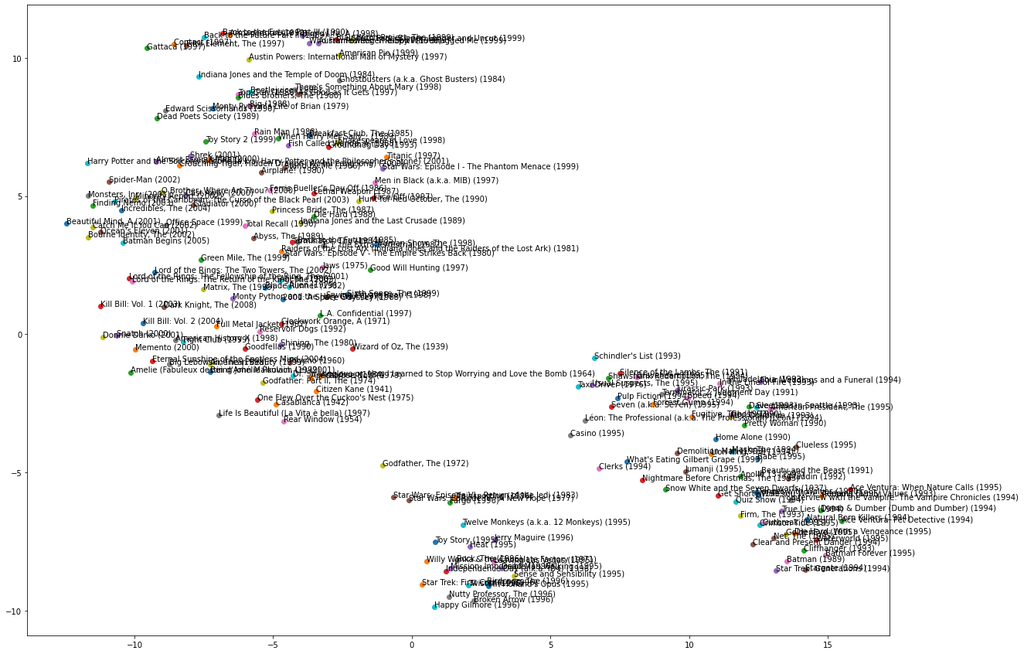

```python
# Plot the movie space embeddings

def plot(embeddings, labels):
    plt.figure(figsize=(20, 15))
    for i, label in enumerate(labels):
        x, y = embeddings[i, :]
        plt.scatter(x, y)
        plt.annotate(label, xy=(x, y))


r = np.arange(1, 200+1)
tsne = TSNE(perplexity=30, n_components=2, init='pca', n_iter=5000, learning_rate=100)
t = tsne.fit_transform(out_embeddings[r, :])
plot(t, [dictionary[i] for i in r])
```